# Cell2Cell | Exploratory data analysis

This analysis uses the training customers from the shared split to examine which account characteristics may help prioritize retention outreach. In the source, churn `Yes` means the customer left during the recorded observation period. `No` means they did not leave during that period.

```r
cleaned <- read.csv("Generated_Data/cleaned_data.csv", na.strings = c("", "NA"))
manifest <- read.csv("Generated_Data/split_manifest.csv")
stopifnot(!anyDuplicated(cleaned$CustomerID), !anyDuplicated(manifest$CustomerID),
          setequal(cleaned$CustomerID, manifest$CustomerID))
training_manifest <- subset(manifest, split == "train")
training <- cleaned[match(training_manifest$CustomerID, cleaned$CustomerID), ]
churned <- training$Churn == "Yes"
baseline <- mean(churned)
knitr::kable(
  data.frame(Outcome = c("Did not churn (No)", "Churned (Yes)"),
             Customers = c(sum(!churned), sum(churned)),
             `Share of training sample` = sprintf("%.1f%%", 100 * c(1 - baseline, baseline)),
             check.names = FALSE),
  format.args = list(big.mark = ","),
  caption = "Observed churn outcomes among training customers"
)
```

Observed churn outcomes among training customers

| Outcome | Customers | Share of training sample |
| --- | --- | --- |
| Did not churn (No) | 27,252 | 71.2% |
| Churned (Yes) | 11,033 | 28.8% |

```r
churn_summary <- function(group) {
  group <- addNA(as.factor(group), ifany = TRUE)
  counts <- table(group, churned)
  n <- rowSums(counts)
  keep <- n > 0
  rate <- counts[keep, "TRUE"] / n[keep]
  data.frame(
    group = ifelse(is.na(rownames(counts)[keep]), "Missing", rownames(counts)[keep]),
    customers = unname(n[keep]),
    training_share = sprintf("%.1f%%", 100 * unname(n[keep]) / length(churned)),
    churned = unname(counts[keep, "TRUE"]),
    churn_pct = round(100 * unname(rate), 1),
    difference_pp = round(100 * (unname(rate) - baseline), 1)
  )
}

chart_colors <- c(blue = "#2B6387", light_blue = "#DCE8F0", high = "#A84C35",
                  baseline = "#BA4116", grid = "#E5EBF0", ink = "#243247")

add_churn_baseline <- function(horizontal_bars = FALSE) {
  baseline_pct <- 100 * baseline
  baseline_color <- chart_colors[["baseline"]]
  if (horizontal_bars) {
    abline(v = baseline_pct, col = baseline_color, lty = 2, lwd = 2)
  } else {
    abline(h = baseline_pct, col = baseline_color, lty = 2, lwd = 2)
  }
  mtext(
    sprintf("Training baseline: %.1f%%", baseline_pct),
    side = 3, line = 0.25, adj = 1, col = baseline_color, cex = 0.76
  )
}

label_churn_bars <- function(positions, rates) {
  text(
    positions, rates / 2, labels = sprintf("%.1f%%", rates),
    col = "white", font = 2, cex = 0.9
  )
}

churn_group_labels <- function(summary) {
  paste0(
    summary$group, "\n(n = ",
    format(summary$customers, big.mark = ",", trim = TRUE),
    "; ", summary$training_share, ")"
  )
}

plot_churn_comparison <- function(summary, title) {
  rows <- rev(seq_len(nrow(summary)))
  rates <- summary$churn_pct[rows]
  groups <- churn_group_labels(summary[rows, ])
  bar_colors <- ifelse(rates > 100 * baseline, chart_colors[["high"]],
                       chart_colors[["blue"]])
  maximum <- max(50, ceiling(max(rates) / 10) * 10)
  old_par <- par(mar = c(4.1, 9.5, 4.4, 1.2))
  on.exit(par(old_par))
  positions <- barplot(
    rates, names.arg = groups, horiz = TRUE, las = 1,
    xlim = c(0, maximum), xaxt = "n", col = bar_colors, border = NA,
    main = title, xlab = "Observed churn", cex.names = 0.85
  )
  ticks <- seq(0, maximum, 10)
  axis(1, at = ticks, labels = paste0(ticks, "%"), col = chart_colors[["grid"]])
  add_churn_baseline(horizontal_bars = TRUE)
  text(rates / 2, positions, labels = sprintf("%.1f%%", rates),
       col = "white", font = 2, cex = 0.9)
}

plot_churn_composition <- function(summary, title, show_baseline = TRUE) {
  churn_share <- 100 * summary$churned / summary$customers
  positions <- barplot(
    rbind("Churned" = churn_share, "Did not churn" = 100 - churn_share),
    names.arg = churn_group_labels(summary),
    ylim = c(0, 115),
    yaxt = "n",
    main = title,
    ylab = "Share of customers",
    col = chart_colors[c("blue", "light_blue")],
    border = NA,
    legend.text = TRUE,
    args.legend = list(x = "top", horiz = TRUE, bty = "n"),
    cex.names = 0.82
  )
  ticks <- seq(0, 100, 25)
  axis(2, at = ticks, labels = paste0(ticks, "%"), las = 1,
       col = chart_colors[["grid"]])
  label_churn_bars(positions, churn_share)
  text(
    positions, churn_share + (100 - churn_share) / 2,
    labels = sprintf("%.1f%%", 100 - churn_share),
    col = "#243247", font = 2, cex = 0.9
  )
  if (show_baseline) {
    add_churn_baseline()
  }
}

tenure <- cut(training$MonthsInService, c(-Inf, 6, 12, 24, 36, Inf))
equipment <- cut(training$CurrentEquipmentDays, c(0, 181, 366, 731, Inf),
                 right = FALSE,
                 labels = c("0–180", "181–365", "366–730", "731+"))
revenue <- cut(training$MonthlyRevenue, c(-Inf, 0, 31, 61, 101, Inf),
               right = FALSE,
               labels = c("Negative", "Under $31", "$31 to <$61",
                          "$61 to <$101", "$101+"))
```

The training churn rate is **28.8%**. A **percentage point** is the difference between two percentages. For example, a group with 31.0% churn is **2.2 percentage points above** the 28.8% training rate (31.0 − 28.8). A negative difference means the group’s churn rate is below the training rate. Smaller groups can have less stable rates, so the tables show customer counts and each group’s percentage of the full training sample. In the charts, percentages beside `n` are group shares. Percentages inside the bars describe outcomes within each group. The dashed orange line marks the training churn rate.

## Milestone 1 assumptions and new hypotheses

Churn may vary nonlinearly with tenure, rise with equipment age, or differ across revenue bands. Prior retention contact may also be associated with churn because customers who contact the team can already be at higher risk.

The Milestone 1 canvas described about 71,000 records and proposed a 30-day forecast. The supplied file contains 51,047 records and the outcome horizon remains unverified. This notebook checks tenure, revenue, and historical retention associations. M1 proposed targeting the top decile and evaluating the top 30%. `03_Variable_Selection.Rmd` compares the M1-style benchmark at those cutoffs and at 20%. The observed churn share describes this sample. The file leaves population monthly churn, contact cost, incremental retention, and campaign profitability unresolved.

```r
tenure_summary <- churn_summary(tenure)
core_groups <- list(
  "Time with the carrier (months)" = tenure,
  "Time with the current handset (days)" = equipment,
  "Average monthly bill (USD)" = revenue,
  "Past calls to the retention team" =
    ifelse(training$RetentionCalls > 0, "Called", "Did not call"),
  "Past acceptance of a retention offer" =
    ifelse(training$RetentionOffersAccepted > 0, "Accepted an offer", "None accepted")
)
for (label in names(core_groups)) {
  cat("\n\n")
  print(knitr::kable(
    churn_summary(core_groups[[label]]),
    caption = label,
    col.names = c("Group", "Customers", "Share of training sample", "Churned", "Churn (%)",
                  "Difference from training rate (percentage points)")
  ))
}
```

Time with the carrier (months)

| Group | Customers | Share of training sample | Churned | Churn (%) | Difference from training rate (percentage points) |
| --- | --- | --- | --- | --- | --- |
| (-Inf,6] | 553 | 1.4% | 103 | 18.6 | -10.2 |
| (6,12] | 12213 | 31.9% | 3277 | 26.8 | -2.0 |
| (12,24] | 16084 | 42.0% | 4991 | 31.0 | 2.2 |
| (24,36] | 7264 | 19.0% | 2068 | 28.5 | -0.3 |
| (36, Inf] | 2171 | 5.7% | 594 | 27.4 | -1.5 |

Time with the current handset (days)

| Group | Customers | Share of training sample | Churned | Churn (%) | Difference from training rate (percentage points) |
| --- | --- | --- | --- | --- | --- |
| 0–180 | 7310 | 19.1% | 1675 | 22.9 | -5.9 |
| 181–365 | 14295 | 37.3% | 3796 | 26.6 | -2.3 |
| 366–730 | 12768 | 33.3% | 4188 | 32.8 | 4.0 |
| 731+ | 3849 | 10.1% | 1361 | 35.4 | 6.5 |
| Missing | 63 | 0.2% | 13 | 20.6 | -8.2 |

Average monthly bill (USD)

| Group | Customers | Share of training sample | Churned | Churn (%) | Difference from training rate (percentage points) |
| --- | --- | --- | --- | --- | --- |
| Negative | 3 | 0.0% | 0 | 0.0 | -28.8 |
| Under $31 | 7606 | 19.9% | 2392 | 31.4 | 2.6 |
| $31 to <$61 | 18259 | 47.7% | 5180 | 28.4 | -0.4 |
| $61 to <$101 | 8218 | 21.5% | 2227 | 27.1 | -1.7 |
| $101+ | 4077 | 10.6% | 1181 | 29.0 | 0.1 |
| Missing | 122 | 0.3% | 53 | 43.4 | 14.6 |

Past calls to the retention team

| Group | Customers | Share of training sample | Churned | Churn (%) | Difference from training rate (percentage points) |
| --- | --- | --- | --- | --- | --- |
| Called | 1313 | 3.4% | 586 | 44.6 | 15.8 |
| Did not call | 36972 | 96.6% | 10447 | 28.3 | -0.6 |

Past acceptance of a retention offer

| Group | Customers | Share of training sample | Churned | Churn (%) | Difference from training rate (percentage points) |
| --- | --- | --- | --- | --- | --- |
| Accepted an offer | 668 | 1.7% | 265 | 39.7 | 10.9 |
| None accepted | 37617 | 98.3% | 10768 | 28.6 | -0.2 |

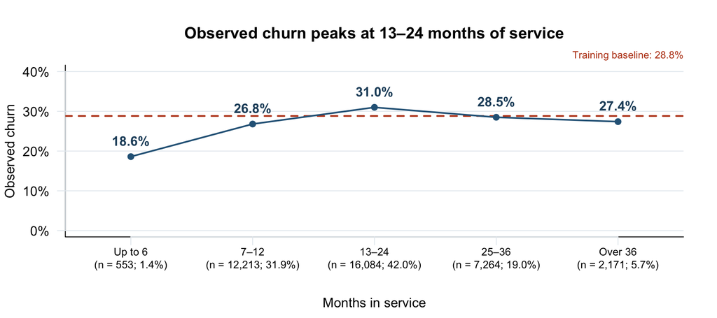

```r
tenure_plot <- tenure_summary
tenure_plot$group <- c("Up to 6", "7–12", "13–24", "25–36", "Over 36")
tenure_positions <- seq_len(nrow(tenure_plot))
plot(
  tenure_positions, tenure_plot$churn_pct,
  type = "n", xaxt = "n", yaxt = "n", bty = "l", ylim = c(0, 40),
  xlim = range(tenure_positions) + c(-0.35, 0.35),
  main = "Observed churn peaks at 13–24 months of service",
  xlab = "", ylab = "Observed churn"
)
tenure_ticks <- seq(0, 40, 10)
abline(h = tenure_ticks, col = chart_colors[["grid"]])
axis(2, at = tenure_ticks, labels = paste0(tenure_ticks, "%"), las = 1,
     col = chart_colors[["grid"]])
axis(1, at = tenure_positions, labels = FALSE, col = chart_colors[["grid"]])
text(
  tenure_positions, par("usr")[3], labels = churn_group_labels(tenure_plot),
  pos = 1, offset = 0.9, xpd = TRUE, cex = 0.8
)
mtext("Months in service", side = 1, line = 3.6)
add_churn_baseline()
lines(tenure_positions, tenure_plot$churn_pct, col = chart_colors[["blue"]], lwd = 2)
points(tenure_positions, tenure_plot$churn_pct, col = chart_colors[["blue"]], pch = 19)
text(
  tenure_positions, tenure_plot$churn_pct,
  labels = sprintf("%.1f%%", tenure_plot$churn_pct),
  pos = 3, offset = 0.7, col = "#234D6A", font = 2
)
```

### What the tenure chart shows

Observed churn rose from **18.6%** in the first six months to **31.0%** at 13–24 months, then fell to **27.4%** beyond 36 months. The focused model represents tenure as a curve so it can capture that change in direction. The screening comparison did not isolate the curve’s gain against a linear tenure term with all other predictors held fixed.

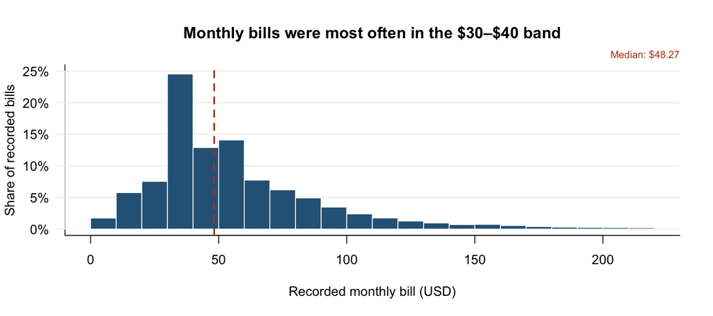

```r
recorded_revenue <- training$MonthlyRevenue[!is.na(training$MonthlyRevenue)]
revenue_breaks <- seq(floor(min(recorded_revenue) / 10) * 10,
                      ceiling(max(recorded_revenue) / 10) * 10, by = 10)
revenue_hist <- hist(recorded_revenue, breaks = revenue_breaks, plot = FALSE)
revenue_limit <- ceiling(unname(quantile(recorded_revenue, 0.99)) / 10) * 10
visible_bins <- revenue_hist$breaks[-1] <= revenue_limit
revenue_shares <- 100 * revenue_hist$counts / length(recorded_revenue)
median_revenue <- median(recorded_revenue)
revenue_ticks <- pretty(c(0, max(revenue_shares[visible_bins])))
most_common_bin <- which.max(revenue_hist$counts)
plot(
  NA_real_, NA_real_, xlim = c(min(revenue_breaks), revenue_limit),
  ylim = range(revenue_ticks), bty = "l", yaxt = "n", xaxs = "i",
  main = sprintf("Monthly bills were most often in the $%d–$%d band",
                 revenue_breaks[most_common_bin], revenue_breaks[most_common_bin + 1]),
  xlab = "Recorded monthly bill (USD)", ylab = "Share of recorded bills"
)
abline(h = revenue_ticks, col = chart_colors[["grid"]])
axis(2, at = revenue_ticks, labels = paste0(revenue_ticks, "%"), las = 1,
     col = chart_colors[["grid"]])
rect(head(revenue_hist$breaks, -1)[visible_bins], 0,
     tail(revenue_hist$breaks, -1)[visible_bins], revenue_shares[visible_bins],
     col = chart_colors[["blue"]], border = "white")
abline(v = median_revenue, col = chart_colors[["baseline"]], lty = 2, lwd = 2)
mtext(sprintf("Median: $%.2f", median_revenue), side = 3, line = 0.25,
      adj = 1, col = chart_colors[["baseline"]], cex = 0.76)
```

The revenue chart uses $10 bins and shows bills through $230. Higher bills are outside the plotted range and make up 1.0% of recorded bills. Each bar’s share uses all recorded bills as the denominator.

### What the revenue chart shows

Monthly bills were most common in the **$30–$40** range, with a median of **$48.27** and a long upper tail. The spread makes monthly revenue useful for distinguishing account value. The focused model retains monthly revenue as a continuous candidate, and the financial analysis uses it to measure observed account value. The distribution alone does not show how much revenue improves churn ranking.

### Why retention history is excluded from prediction

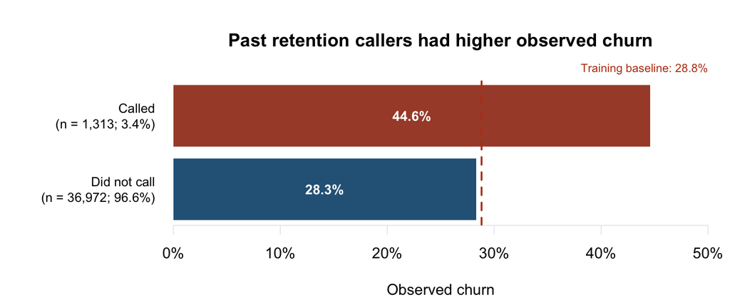

```r
retention_groups <- ifelse(training$RetentionCalls > 0, "Called", "Did not call")
plot_churn_comparison(churn_summary(retention_groups), "Past retention callers had higher observed churn")
```

Customers who had called the retention team showed **44.6%** observed churn (1,313 customers), compared with **28.3%** among customers who had not called (36,972 customers). Two issues limit how the team can use that comparison.

- **Timing and data leakage.** The CSV gives no dates for retention calls or offer acceptance. For example, a customer might call the retention team after deciding to cancel. If that call happened after the date when the model would have scored the customer, using it would give the historical model information the team would have had no access to then. Cross-validation alone cannot catch this timing problem.
- **Who receives retention help.** Customers already considering leaving may be more likely to call or receive an offer. Their higher observed churn rate may reflect their higher starting risk. Comparing churn rates across these groups cannot determine whether the offers helped.

`RetentionCalls`, `MadeCallToRetentionTeam`, and `RetentionOffersAccepted` remain descriptive fields. Using them for prediction would require dated records and a definition that counts only events already recorded at the scoring date.

### Additional churn comparisons, including tenure by equipment age

```r
change_band <- function(x) {
  factor(sign(x), levels = c(-1, 0, 1), labels = c("Decrease", "No change", "Increase"))
}

groups <- with(training, list(
  handset_models = cut(HandsetModels, c(-Inf, 1, 2, Inf)),
  web_capable = HandsetWebCapable,
  usage_change = change_band(PercChangeMinutes),
  revenue_change = change_band(PercChangeRevenues),
  dropped_calls = DroppedCalls > 0,
  blocked_calls = BlockedCalls > 0,
  customer_care_calls = CustomerCareCalls > 0,
  overage = OverageMinutes > 0,
  revenue_above_recurring_charge = MonthlyRevenue > TotalRecurringCharge,
  multiple_active_lines = ActiveSubs > 1,
  tenure_by_equipment = interaction(tenure, equipment, drop = TRUE, sep = " / ")
))
for (label in names(groups)) {
  values <- groups[[label]]
  if (is.logical(values)) {
    values <- ifelse(values, "Yes", "No")
  }
  cat("\n\n")
  print(knitr::kable(
    churn_summary(values),
    caption = tools::toTitleCase(gsub("_", " ", label)),
    col.names = c("Group", "Customers", "Share of training sample", "Churned", "Churn (%)",
                  "Difference from training rate (percentage points)")
  ))
}
```

Handset Models

| Group | Customers | Share of training sample | Churned | Churn (%) | Difference from training rate (percentage points) |
| --- | --- | --- | --- | --- | --- |
| (-Inf,1] | 23947 | 62.5% | 7237 | 30.2 | 1.4 |
| (1,2] | 9764 | 25.5% | 2644 | 27.1 | -1.7 |
| (2, Inf] | 4574 | 11.9% | 1152 | 25.2 | -3.6 |

Web Capable

| Group | Customers | Share of training sample | Churned | Churn (%) | Difference from training rate (percentage points) |
| --- | --- | --- | --- | --- | --- |
| No | 3713 | 9.7% | 1394 | 37.5 | 8.7 |
| Yes | 34572 | 90.3% | 9639 | 27.9 | -0.9 |

Usage Change

| Group | Customers | Share of training sample | Churned | Churn (%) | Difference from training rate (percentage points) |
| --- | --- | --- | --- | --- | --- |
| Decrease | 20046 | 52.4% | 6037 | 30.1 | 1.3 |
| No change | 839 | 2.2% | 394 | 47.0 | 18.1 |
| Increase | 17123 | 44.7% | 4445 | 26.0 | -2.9 |
| Missing | 277 | 0.7% | 157 | 56.7 | 27.9 |

Revenue Change

| Group | Customers | Share of training sample | Churned | Churn (%) | Difference from training rate (percentage points) |
| --- | --- | --- | --- | --- | --- |
| Decrease | 21241 | 55.5% | 6027 | 28.4 | -0.4 |
| No change | 4354 | 11.4% | 1314 | 30.2 | 1.4 |
| Increase | 12413 | 32.4% | 3535 | 28.5 | -0.3 |
| Missing | 277 | 0.7% | 157 | 56.7 | 27.9 |

Dropped Calls

| Group | Customers | Share of training sample | Churned | Churn (%) | Difference from training rate (percentage points) |
| --- | --- | --- | --- | --- | --- |
| No | 5813 | 15.2% | 1901 | 32.7 | 3.9 |
| Yes | 32472 | 84.8% | 9132 | 28.1 | -0.7 |

Blocked Calls

| Group | Customers | Share of training sample | Churned | Churn (%) | Difference from training rate (percentage points) |
| --- | --- | --- | --- | --- | --- |
| No | 10510 | 27.5% | 3166 | 30.1 | 1.3 |
| Yes | 27775 | 72.5% | 7867 | 28.3 | -0.5 |

Customer Care Calls

| Group | Customers | Share of training sample | Churned | Churn (%) | Difference from training rate (percentage points) |
| --- | --- | --- | --- | --- | --- |
| No | 21038 | 55.0% | 6454 | 30.7 | 1.9 |
| Yes | 17247 | 45.0% | 4579 | 26.5 | -2.3 |

Overage

| Group | Customers | Share of training sample | Churned | Churn (%) | Difference from training rate (percentage points) |
| --- | --- | --- | --- | --- | --- |
| No | 17443 | 45.6% | 4952 | 28.4 | -0.4 |
| Yes | 20720 | 54.1% | 6028 | 29.1 | 0.3 |
| Missing | 122 | 0.3% | 53 | 43.4 | 14.6 |

Revenue above Recurring Charge

| Group | Customers | Share of training sample | Churned | Churn (%) | Difference from training rate (percentage points) |
| --- | --- | --- | --- | --- | --- |
| No | 14420 | 37.7% | 3817 | 26.5 | -2.3 |
| Yes | 23743 | 62.0% | 7163 | 30.2 | 1.4 |
| Missing | 122 | 0.3% | 53 | 43.4 | 14.6 |

Multiple Active Lines

| Group | Customers | Share of training sample | Churned | Churn (%) | Difference from training rate (percentage points) |
| --- | --- | --- | --- | --- | --- |
| No | 27186 | 71.0% | 7645 | 28.1 | -0.7 |
| Yes | 11099 | 29.0% | 3388 | 30.5 | 1.7 |

Tenure by Equipment

| Group | Customers | Share of training sample | Churned | Churn (%) | Difference from training rate (percentage points) |
| --- | --- | --- | --- | --- | --- |
| (-Inf,6] / 0–180 | 89 | 0.2% | 20 | 22.5 | -6.3 |
| (6,12] / 0–180 | 2031 | 5.3% | 536 | 26.4 | -2.4 |
| (12,24] / 0–180 | 3238 | 8.5% | 807 | 24.9 | -3.9 |
| (24,36] / 0–180 | 1486 | 3.9% | 241 | 16.2 | -12.6 |
| (36, Inf] / 0–180 | 466 | 1.2% | 71 | 15.2 | -13.6 |
| (-Inf,6] / 181–365 | 464 | 1.2% | 83 | 17.9 | -10.9 |
| (6,12] / 181–365 | 9881 | 25.8% | 2626 | 26.6 | -2.2 |
| (12,24] / 181–365 | 2263 | 5.9% | 680 | 30.0 | 1.2 |
| (24,36] / 181–365 | 1293 | 3.4% | 327 | 25.3 | -3.5 |
| (36, Inf] / 181–365 | 394 | 1.0% | 80 | 20.3 | -8.5 |
| (6,12] / 366–730 | 280 | 0.7% | 111 | 39.6 | 10.8 |
| (12,24] / 366–730 | 10463 | 27.3% | 3458 | 33.0 | 4.2 |
| (24,36] / 366–730 | 1445 | 3.8% | 459 | 31.8 | 2.9 |
| (36, Inf] / 366–730 | 580 | 1.5% | 160 | 27.6 | -1.2 |
| (12,24] / 731+ | 100 | 0.3% | 38 | 38.0 | 9.2 |
| (24,36] / 731+ | 3023 | 7.9% | 1040 | 34.4 | 5.6 |
| (36, Inf] / 731+ | 726 | 1.9% | 283 | 39.0 | 10.2 |
| Missing | 63 | 0.2% | 13 | 20.6 | -8.2 |

## Device, roaming, and subscription relationships

### Handset web capability

A web-capable handset may reflect a different device or service experience. The chart compares observed churn for customers with and without that capability.

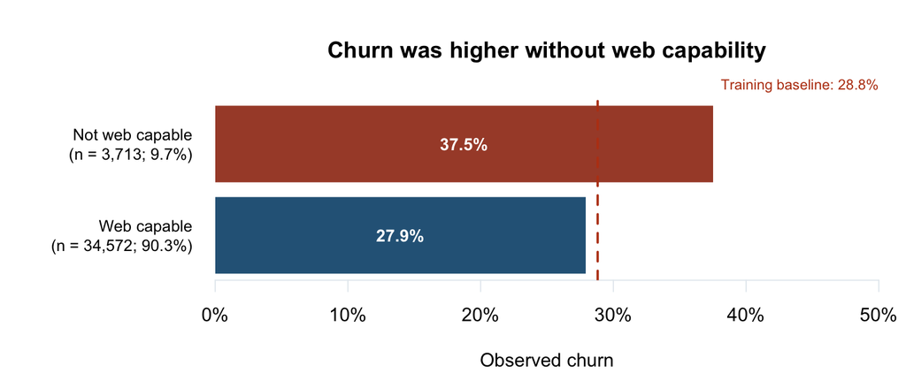

```r
web_groups <- factor(
  training$HandsetWebCapable,
  levels = c("No", "Yes"),
  labels = c("Not web capable", "Web capable")
)
web_summary <- churn_summary(web_groups)
plot_churn_comparison(web_summary, "Churn was higher without web capability")
```

Observed churn was **37.5%** among customers whose handsets lacked web capability (3,713 customers) and **27.9%** among those with web-capable handsets (34,572 customers). The **9.6 percentage-point gap** supports testing web capability as a predictor. Adding web capability alone increased 10% outreach lift from **1.364 to 1.401**, so the focused candidate retains it. The comparison cannot establish whether upgrading a handset changes churn risk.

### Roaming activity, churn, and billing

`RoamingCalls` records average monthly roaming calls, so values can be fractional. The first chart groups zero as no roaming and any positive value as recorded roaming. For example, 0 is “No roaming,” while 2 and 15 are both “Any roaming.” Missing values remain in a separate group.

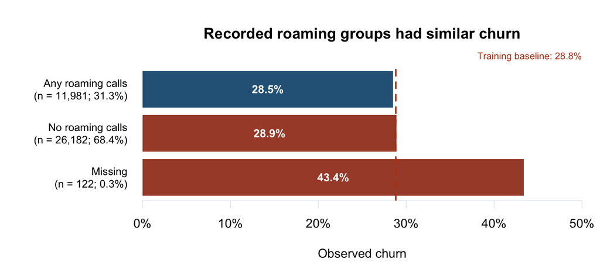

```r
roaming_groups <- ifelse(training$RoamingCalls > 0, "Any roaming calls", "No roaming calls")
plot_churn_comparison(churn_summary(roaming_groups), "Recorded roaming groups had similar churn")
```

Customers with recorded roaming activity had **28.5%** observed churn, compared with **28.9%** for those with no roaming calls. The missing-roaming group had **43.4%** churn and represented **0.3%** of the training sample. The near-equal rates for customers with and without recorded roaming give little reason to add a binary roaming flag to the focused model.

#### Is churn higher at heavier roaming levels?

A yes/no flag combines light and heavy roaming. The next chart separates positive values into ranges so differences within the roaming group are visible.

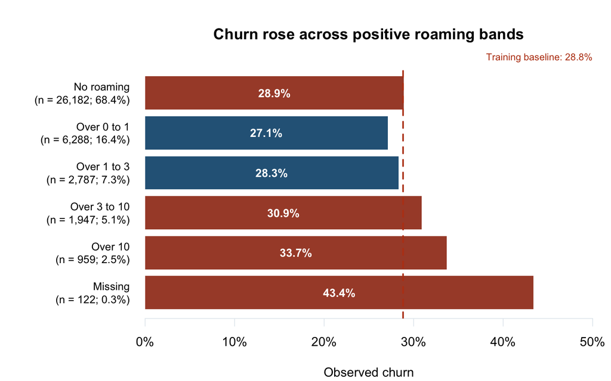

```r
roaming_band <- cut(
  training$RoamingCalls,
  breaks = c(-Inf, 0, 1, 3, 10, Inf),
  labels = c("No roaming", "Over 0 to 1", "Over 1 to 3", "Over 3 to 10", "Over 10")
)
roaming_summary <- churn_summary(roaming_band)
plot_churn_comparison(roaming_summary, "Churn rose across positive roaming bands")
```

Among customers with recorded roaming, observed churn increased from **27.1%** in the lightest band to **33.7%** in the heaviest band. The heaviest band contained **959 customers**, or **2.5%** of the training sample. That concentration explains why a yes/no flag can hide the heavier-use pattern. Adding the raw roaming field raised 10% lift from **1.364 to 1.367**, so it remains in the broader challenger. The intensity bands were descriptive and their added predictive value remains untested.

#### Does heavier roaming go with a larger bill gap?

The billing gap is the recorded monthly bill minus the fixed plan charge. We compare its median and middle 50% within each roaming band. The chart uses accounts with both recorded roaming and a calculable billing gap.

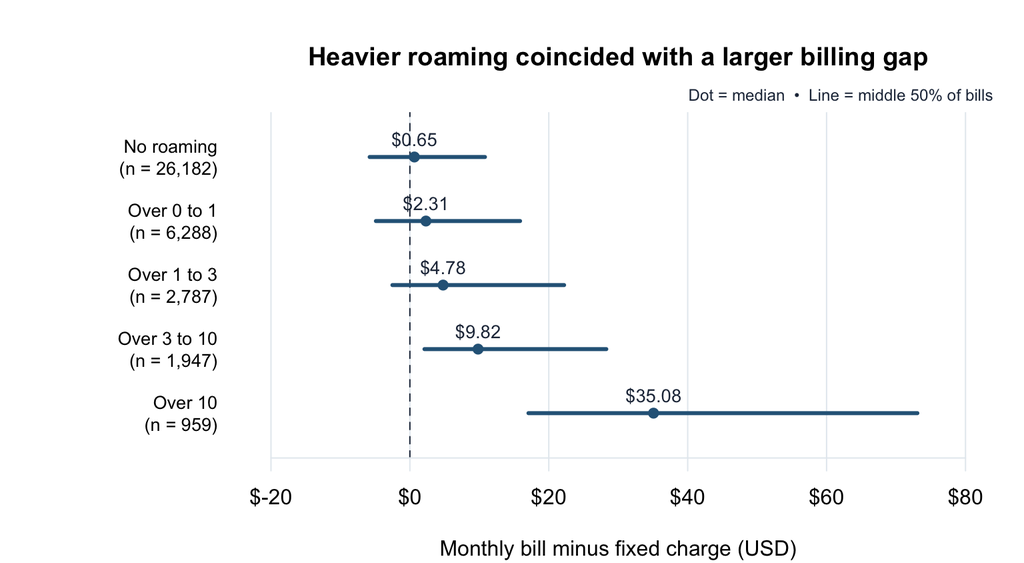

```r
roaming_bill_gap <- training$MonthlyRevenue - training$TotalRecurringCharge
gap_by_roaming <- split(roaming_bill_gap, roaming_band)
observed_gap_counts <- vapply(gap_by_roaming, function(x) sum(!is.na(x)), integer(1))
gap_quantiles <- vapply(gap_by_roaming, quantile, numeric(3),
                        probs = c(0.25, 0.50, 0.75), na.rm = TRUE)
rows <- rev(seq_along(gap_by_roaming))
positions <- seq_along(rows)
labels <- paste0(
  names(gap_by_roaming)[rows], "\n(n = ",
  format(observed_gap_counts[rows], big.mark = ",", trim = TRUE), ")"
)
gap_ticks <- pretty(range(0, gap_quantiles))

old_par <- par(mar = c(4.1, 9.5, 4.4, 1.2))
plot(
  gap_quantiles[2, rows], positions, type = "n", axes = FALSE, bty = "n",
  xlim = range(gap_ticks), ylim = c(0.5, length(rows) + 0.5),
  main = "Heavier roaming coincided with a larger billing gap",
  xlab = "Monthly bill minus fixed charge (USD)", ylab = ""
)
abline(v = gap_ticks, col = chart_colors[["grid"]])
abline(v = 0, col = chart_colors[["ink"]], lty = 2)
axis(1, at = gap_ticks, labels = paste0("$", gap_ticks), col = chart_colors[["grid"]])
axis(2, at = positions, labels = labels, las = 1, tick = FALSE, cex.axis = 0.85)
segments(gap_quantiles[1, rows], positions, gap_quantiles[3, rows], positions,
         col = chart_colors[["blue"]], lwd = 3)
points(gap_quantiles[2, rows], positions, pch = 19, col = chart_colors[["blue"]])
text(gap_quantiles[2, rows], positions, labels = sprintf("$%.2f", gap_quantiles[2, rows]),
     pos = 3, offset = 0.45, cex = 0.86, col = chart_colors[["ink"]])
mtext("Dot = median  •  Line = middle 50% of bills", side = 3, line = 0.25,
      adj = 1, cex = 0.76, col = chart_colors[["ink"]])
```

```r
par(old_par)
```

#### What this means

The median billing gap was **$0.65** without roaming and **$35.08** in the heaviest roaming band. This gives the billing gap a business interpretation as a plan-review signal and suggests checking whether roaming adds information beyond billing. The limited lift gain from raw roaming supports leaving it outside the focused model. The gap can include multiple billing components. Without itemized bills, the analysis cannot determine how much came from roaming fees or whether those fees contributed to churn.

### Active subscriptions and churn

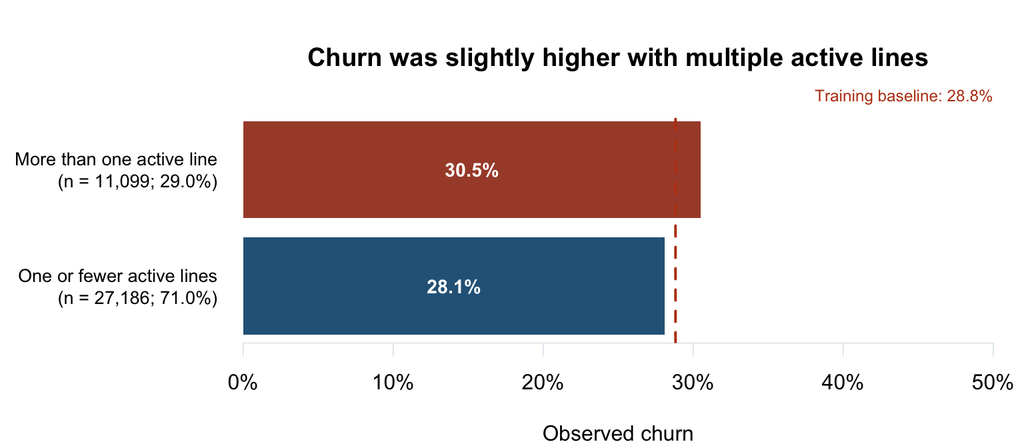

```r
active_line_groups <- ifelse(training$ActiveSubs > 1, "More than one active line",
                             "One or fewer active lines")
plot_churn_comparison(churn_summary(active_line_groups), "Churn was slightly higher with multiple active lines")
```

Observed churn was **30.5%** for accounts with more than one active line and **28.1%** for accounts with one or fewer. Adding active and distinct subscription counts together increased 10% lift from **1.364 to 1.420**. The focused candidate retains both counts. The block comparison does not isolate the contribution of active lines alone.

## Predictor eligibility and exploration

Fields were screened for their relevance to an account review and whether they could plausibly be available before outreach. The model comparisons assume standard account and usage fields are available at scoring time. Production use still requires verification of their measurement dates.

| Candidate block | Business rationale |
| --- | --- |
| Tenure, equipment age, service friction, and billing | Use the existing benchmark to represent lifecycle, service experience, and account value. |
| Handsets | Web capability, refurbishment, price, and device counts can reflect device constraints and upgrade history. |
| Roaming and overage | Usage outside a typical plan may affect the customer’s bill or indicate an unmet plan need. |
| Subscription and account history | Current and historical lines, recent-user indicators, and referrals describe the account relationship. |
| Calling activity | Call volume, direction, time of use, and call features describe how customers use the service. |
| Alternate representations | Compare recurring charge in place of billing gap, and combined dropped/blocked calls in place of separate counts. |

The response and customer ID have dedicated roles. Prior retention contacts and offers require verified timing. Geography, household and credit data, and marketing or purchasing profiles are deferred pending a documented rationale and eligibility review.

EDA and variable selection share feature definitions and field groups in `R/preprocessing.R`.

```r
source("R/preprocessing.R")
feature_groups <- cell2cell_feature_groups()
benchmark <- feature_groups$benchmark
additional_blocks <- feature_groups$additional_blocks
alternate_fields <- feature_groups$alternate_fields
eligible <- c(benchmark, unlist(additional_blocks, use.names = FALSE), alternate_fields)
```

```r
field_groups <- c(
  list(outcome_or_key = c("Churn", "CustomerID"), benchmark = benchmark),
  additional_blocks,
  list(
    alternate_representation = alternate_fields,
    timing_review = c("RetentionCalls", "RetentionOffersAccepted",
                      "MadeCallToRetentionTeam"),
    geography_review = "ServiceArea",
    policy_review = c(
      "AgeHH1", "AgeHH2", "ChildrenInHH", "TruckOwner", "RVOwner",
      "Homeownership", "BuysViaMailOrder", "RespondsToMailOffers",
      "OptOutMailings", "NonUSTravel", "OwnsComputer", "HasCreditCard",
      "IncomeGroup", "OwnsMotorcycle", "AdjustmentsToCreditRating",
      "CreditRating", "PrizmCode", "Occupation", "MaritalStatus"
    )
  )
)
assigned_fields <- unlist(field_groups, use.names = FALSE)
stopifnot(!anyDuplicated(assigned_fields), setequal(names(cleaned), assigned_fields))
field_review <- stack(field_groups)
names(field_review) <- c("field", "group")
field_review$missing <- unname(colSums(is.na(training[field_review$field])))
field_review$distinct_observed <- vapply(training[field_review$field], function(x) {
  length(unique(x[!is.na(x)]))
}, integer(1))
knitr::kable(field_review)
```

| field | group | missing | distinct_observed |
| --- | --- | --- | --- |
| Churn | outcome_or_key | 0 | 2 |
| CustomerID | outcome_or_key | 0 | 38285 |
| MonthsInService | benchmark | 0 | 56 |
| CurrentEquipmentDays | benchmark | 63 | 1386 |
| PercChangeMinutes | benchmark | 277 | 2086 |
| DroppedCalls | benchmark | 0 | 272 |
| BlockedCalls | benchmark | 0 | 343 |
| CustomerCareCalls | benchmark | 0 | 168 |
| MonthlyRevenue | benchmark | 122 | 11309 |
| PercChangeRevenues | benchmark | 277 | 2645 |
| HandsetWebCapable | handset | 0 | 2 |
| HandsetRefurbished | handset | 0 | 2 |
| Handsets | handset | 0 | 22 |
| HandsetModels | handset | 0 | 13 |
| HandsetPrice | handset | 21812 | 15 |
| RoamingCalls | roaming | 122 | 477 |
| OverageMinutes | overage | 122 | 690 |
| UniqueSubs | subscriptions | 0 | 14 |
| ActiveSubs | subscriptions | 0 | 10 |
| NewCellphoneUser | account_history | 0 | 2 |
| NotNewCellphoneUser | account_history | 0 | 2 |
| ReferralsMadeBySubscriber | account_history | 0 | 13 |
| MonthlyMinutes | calling | 122 | 2558 |
| DirectorAssistedCalls | calling | 122 | 137 |
| UnansweredCalls | calling | 0 | 786 |
| ThreewayCalls | calling | 0 | 74 |
| ReceivedCalls | calling | 0 | 5586 |
| OutboundCalls | calling | 0 | 735 |
| InboundCalls | calling | 0 | 442 |
| PeakCallsInOut | calling | 0 | 1708 |
| OffPeakCallsInOut | calling | 0 | 1555 |
| CallForwardingCalls | calling | 0 | 26 |
| CallWaitingCalls | calling | 0 | 212 |
| TotalRecurringCharge | alternate_representation | 122 | 202 |
| DroppedBlockedCalls | alternate_representation | 0 | 419 |
| RetentionCalls | timing_review | 0 | 5 |
| RetentionOffersAccepted | timing_review | 0 | 4 |
| MadeCallToRetentionTeam | timing_review | 0 | 2 |
| ServiceArea | geography_review | 20 | 723 |
| AgeHH1 | policy_review | 665 | 42 |
| AgeHH2 | policy_review | 665 | 43 |
| ChildrenInHH | policy_review | 0 | 2 |
| TruckOwner | policy_review | 0 | 2 |
| RVOwner | policy_review | 0 | 2 |
| Homeownership | policy_review | 0 | 2 |
| BuysViaMailOrder | policy_review | 0 | 2 |
| RespondsToMailOffers | policy_review | 0 | 2 |
| OptOutMailings | policy_review | 0 | 2 |
| NonUSTravel | policy_review | 0 | 2 |
| OwnsComputer | policy_review | 0 | 2 |
| HasCreditCard | policy_review | 0 | 2 |
| IncomeGroup | policy_review | 0 | 10 |
| OwnsMotorcycle | policy_review | 0 | 2 |
| AdjustmentsToCreditRating | policy_review | 0 | 15 |
| CreditRating | policy_review | 0 | 7 |
| PrizmCode | policy_review | 0 | 4 |
| Occupation | policy_review | 0 | 8 |
| MaritalStatus | policy_review | 0 | 3 |

For eligible numeric variables, the profiles below use up to four bands based on distinct training quantiles. Repeated cut points are combined so zero-heavy fields can have fewer bands. The roaming profile explicitly compares zero and positive use. Categorical fields use recorded levels. These bands summarize churn and group sizes. The models use the original numeric values.

### Churn profiles for individual eligible predictors

```r
eligible <- c(benchmark, unlist(additional_blocks, use.names = FALSE), alternate_fields)
for (field in eligible) {
  values <- training[[field]]
  group <- values
  if (is.numeric(values) && length(unique(na.omit(values))) > 8L) {
    breaks <- unique(quantile(values, seq(0, 1, by = 0.25), na.rm = TRUE))
    group <- cut(values, breaks, include.lowest = TRUE, dig.lab = 6)
  }
  if (field == "RoamingCalls") {
    group <- ifelse(values == 0, "Zero", ifelse(values > 0, "Positive", "Negative"))
  }
  cat("\n\n")
  print(knitr::kable(
    churn_summary(group),
    caption = field,
    col.names = c("Group", "Customers", "Share of training sample", "Churned", "Churn (%)",
                  "Difference from training rate (percentage points)")
  ))
}
```

MonthsInService

| Group | Customers | Share of training sample | Churned | Churn (%) | Difference from training rate (percentage points) |
| --- | --- | --- | --- | --- | --- |
| [6,11] | 10711 | 28.0% | 2563 | 23.9 | -4.9 |
| (11,16] | 8555 | 22.3% | 2934 | 34.3 | 5.5 |
| (16,24] | 9584 | 25.0% | 2874 | 30.0 | 1.2 |
| (24,61] | 9435 | 24.6% | 2662 | 28.2 | -0.6 |

CurrentEquipmentDays

| Group | Customers | Share of training sample | Churned | Churn (%) | Difference from training rate (percentage points) |
| --- | --- | --- | --- | --- | --- |
| [0,205.25] | 9556 | 25.0% | 2101 | 22.0 | -6.8 |
| (205.25,330] | 9575 | 25.0% | 2372 | 24.8 | -4.0 |
| (330,516] | 9555 | 25.0% | 3345 | 35.0 | 6.2 |
| (516,1812] | 9536 | 24.9% | 3202 | 33.6 | 4.8 |
| Missing | 63 | 0.2% | 13 | 20.6 | -8.2 |

PercChangeMinutes

| Group | Customers | Share of training sample | Churned | Churn (%) | Difference from training rate (percentage points) |
| --- | --- | --- | --- | --- | --- |
| [-3406,-83] | 9505 | 24.8% | 3026 | 31.8 | 3.0 |
| (-83,-5] | 9603 | 25.1% | 2755 | 28.7 | -0.1 |
| (-5,66] | 9447 | 24.7% | 2556 | 27.1 | -1.8 |
| (66,5192] | 9453 | 24.7% | 2539 | 26.9 | -2.0 |
| Missing | 277 | 0.7% | 157 | 56.7 | 27.9 |

DroppedCalls

| Group | Customers | Share of training sample | Churned | Churn (%) | Difference from training rate (percentage points) |
| --- | --- | --- | --- | --- | --- |
| [0,0.7] | 9764 | 25.5% | 3016 | 30.9 | 2.1 |
| (0.7,3] | 9915 | 25.9% | 2837 | 28.6 | -0.2 |
| (3,7.7] | 9412 | 24.6% | 2651 | 28.2 | -0.7 |
| (7.7,221.7] | 9194 | 24.0% | 2529 | 27.5 | -1.3 |

BlockedCalls

| Group | Customers | Share of training sample | Churned | Churn (%) | Difference from training rate (percentage points) |
| --- | --- | --- | --- | --- | --- |
| [0,1] | 20063 | 52.4% | 5915 | 29.5 | 0.7 |
| (1,3.7] | 9060 | 23.7% | 2566 | 28.3 | -0.5 |
| (3.7,384.3] | 9162 | 23.9% | 2552 | 27.9 | -1.0 |

CustomerCareCalls

| Group | Customers | Share of training sample | Churned | Churn (%) | Difference from training rate (percentage points) |
| --- | --- | --- | --- | --- | --- |
| [0,1.7] | 29294 | 76.5% | 8798 | 30.0 | 1.2 |
| (1.7,273] | 8991 | 23.5% | 2235 | 24.9 | -4.0 |

MonthlyRevenue

| Group | Customers | Share of training sample | Churned | Churn (%) | Difference from training rate (percentage points) |
| --- | --- | --- | --- | --- | --- |
| [-6.17,33.51] | 9552 | 24.9% | 2988 | 31.3 | 2.5 |
| (33.51,48.27] | 9532 | 24.9% | 2613 | 27.4 | -1.4 |
| (48.27,70.965] | 9538 | 24.9% | 2732 | 28.6 | -0.2 |
| (70.965,1223.38] | 9541 | 24.9% | 2647 | 27.7 | -1.1 |
| Missing | 122 | 0.3% | 53 | 43.4 | 14.6 |

PercChangeRevenues

| Group | Customers | Share of training sample | Churned | Churn (%) | Difference from training rate (percentage points) |
| --- | --- | --- | --- | --- | --- |
| [-1107.7,-7] | 9511 | 24.8% | 2788 | 29.3 | 0.5 |
| (-7,-0.3] | 10103 | 26.4% | 2792 | 27.6 | -1.2 |
| (-0.3,1.7] | 8920 | 23.3% | 2527 | 28.3 | -0.5 |
| (1.7,2483.5] | 9474 | 24.7% | 2769 | 29.2 | 0.4 |
| Missing | 277 | 0.7% | 157 | 56.7 | 27.9 |

HandsetWebCapable

| Group | Customers | Share of training sample | Churned | Churn (%) | Difference from training rate (percentage points) |
| --- | --- | --- | --- | --- | --- |
| No | 3713 | 9.7% | 1394 | 37.5 | 8.7 |
| Yes | 34572 | 90.3% | 9639 | 27.9 | -0.9 |

HandsetRefurbished

| Group | Customers | Share of training sample | Churned | Churn (%) | Difference from training rate (percentage points) |
| --- | --- | --- | --- | --- | --- |
| No | 33003 | 86.2% | 9327 | 28.3 | -0.6 |
| Yes | 5282 | 13.8% | 1706 | 32.3 | 3.5 |

Handsets

| Group | Customers | Share of training sample | Churned | Churn (%) | Difference from training rate (percentage points) |
| --- | --- | --- | --- | --- | --- |
| [1,2] | 31225 | 81.6% | 9141 | 29.3 | 0.5 |
| (2,24] | 7060 | 18.4% | 1892 | 26.8 | -2.0 |

HandsetModels

| Group | Customers | Share of training sample | Churned | Churn (%) | Difference from training rate (percentage points) |
| --- | --- | --- | --- | --- | --- |
| [1,2] | 33711 | 88.1% | 9881 | 29.3 | 0.5 |
| (2,15] | 4574 | 11.9% | 1152 | 25.2 | -3.6 |

HandsetPrice

| Group | Customers | Share of training sample | Churned | Churn (%) | Difference from training rate (percentage points) |
| --- | --- | --- | --- | --- | --- |
| [10,30] | 6939 | 18.1% | 1852 | 26.7 | -2.1 |
| (30,60] | 1501 | 3.9% | 423 | 28.2 | -0.6 |
| (60,130] | 3946 | 10.3% | 1063 | 26.9 | -1.9 |
| (130,500] | 4087 | 10.7% | 1116 | 27.3 | -1.5 |
| Missing | 21812 | 57.0% | 6579 | 30.2 | 1.3 |

RoamingCalls

| Group | Customers | Share of training sample | Churned | Churn (%) | Difference from training rate (percentage points) |
| --- | --- | --- | --- | --- | --- |
| Positive | 11981 | 31.3% | 3415 | 28.5 | -0.3 |
| Zero | 26182 | 68.4% | 7565 | 28.9 | 0.1 |
| Missing | 122 | 0.3% | 53 | 43.4 | 14.6 |

OverageMinutes

| Group | Customers | Share of training sample | Churned | Churn (%) | Difference from training rate (percentage points) |
| --- | --- | --- | --- | --- | --- |
| [0,3] | 19395 | 50.7% | 5457 | 28.1 | -0.7 |
| (3,40] | 9229 | 24.1% | 2580 | 28.0 | -0.9 |
| (40,4321] | 9539 | 24.9% | 2943 | 30.9 | 2.0 |
| Missing | 122 | 0.3% | 53 | 43.4 | 14.6 |

UniqueSubs

| Group | Customers | Share of training sample | Churned | Churn (%) | Difference from training rate (percentage points) |
| --- | --- | --- | --- | --- | --- |
| [1,2] | 34449 | 90.0% | 9814 | 28.5 | -0.3 |
| (2,18] | 3836 | 10.0% | 1219 | 31.8 | 3.0 |

ActiveSubs

| Group | Customers | Share of training sample | Churned | Churn (%) | Difference from training rate (percentage points) |
| --- | --- | --- | --- | --- | --- |
| [0,1] | 27186 | 71.0% | 7645 | 28.1 | -0.7 |
| (1,2] | 9201 | 24.0% | 2880 | 31.3 | 2.5 |
| (2,11] | 1898 | 5.0% | 508 | 26.8 | -2.1 |

NewCellphoneUser

| Group | Customers | Share of training sample | Churned | Churn (%) | Difference from training rate (percentage points) |
| --- | --- | --- | --- | --- | --- |
| No | 30954 | 80.9% | 8972 | 29.0 | 0.2 |
| Yes | 7331 | 19.1% | 2061 | 28.1 | -0.7 |

NotNewCellphoneUser

| Group | Customers | Share of training sample | Churned | Churn (%) | Difference from training rate (percentage points) |
| --- | --- | --- | --- | --- | --- |
| No | 33086 | 86.4% | 9489 | 28.7 | -0.1 |
| Yes | 5199 | 13.6% | 1544 | 29.7 | 0.9 |

ReferralsMadeBySubscriber

| Group | Customers | Share of training sample | Churned | Churn (%) | Difference from training rate (percentage points) |
| --- | --- | --- | --- | --- | --- |
| [0,35] | 38285 | 100.0% | 11033 | 28.8 | 0 |

MonthlyMinutes

| Group | Customers | Share of training sample | Churned | Churn (%) | Difference from training rate (percentage points) |
| --- | --- | --- | --- | --- | --- |
| [0,157] | 9567 | 25.0% | 3138 | 32.8 | 4.0 |
| (157,365] | 9522 | 24.9% | 2755 | 28.9 | 0.1 |
| (365,718] | 9539 | 24.9% | 2617 | 27.4 | -1.4 |
| (718,7359] | 9535 | 24.9% | 2470 | 25.9 | -2.9 |
| Missing | 122 | 0.3% | 53 | 43.4 | 14.6 |

DirectorAssistedCalls

| Group | Customers | Share of training sample | Churned | Churn (%) | Difference from training rate (percentage points) |
| --- | --- | --- | --- | --- | --- |
| [0,0.25] | 23461 | 61.3% | 6982 | 29.8 | 0.9 |
| (0.25,0.99] | 6575 | 17.2% | 1818 | 27.7 | -1.2 |
| (0.99,159.39] | 8127 | 21.2% | 2180 | 26.8 | -2.0 |
| Missing | 122 | 0.3% | 53 | 43.4 | 14.6 |

UnansweredCalls

| Group | Customers | Share of training sample | Churned | Churn (%) | Difference from training rate (percentage points) |
| --- | --- | --- | --- | --- | --- |
| [0,5] | 9649 | 25.2% | 3072 | 31.8 | 3.0 |
| (5,16] | 9601 | 25.1% | 2757 | 28.7 | -0.1 |
| (16,36.3] | 9530 | 24.9% | 2701 | 28.3 | -0.5 |
| (36.3,814.3] | 9505 | 24.8% | 2503 | 26.3 | -2.5 |

ThreewayCalls

| Group | Customers | Share of training sample | Churned | Churn (%) | Difference from training rate (percentage points) |
| --- | --- | --- | --- | --- | --- |
| [0,0.3] | 32405 | 84.6% | 9511 | 29.4 | 0.5 |
| (0.3,66] | 5880 | 15.4% | 1522 | 25.9 | -2.9 |

ReceivedCalls

| Group | Customers | Share of training sample | Churned | Churn (%) | Difference from training rate (percentage points) |
| --- | --- | --- | --- | --- | --- |
| [0,8.2] | 9601 | 25.1% | 3086 | 32.1 | 3.3 |
| (8.2,52.3] | 9542 | 24.9% | 2749 | 28.8 | 0.0 |
| (52.3,153.1] | 9574 | 25.0% | 2642 | 27.6 | -1.2 |
| (153.1,2619.3] | 9568 | 25.0% | 2556 | 26.7 | -2.1 |

OutboundCalls

| Group | Customers | Share of training sample | Churned | Churn (%) | Difference from training rate (percentage points) |
| --- | --- | --- | --- | --- | --- |
| [0,3.3] | 9942 | 26.0% | 3203 | 32.2 | 3.4 |
| (3.3,13.3] | 9263 | 24.2% | 2621 | 28.3 | -0.5 |
| (13.3,33.7] | 9596 | 25.1% | 2680 | 27.9 | -0.9 |
| (33.7,644.3] | 9484 | 24.8% | 2529 | 26.7 | -2.2 |

InboundCalls

| Group | Customers | Share of training sample | Churned | Churn (%) | Difference from training rate (percentage points) |
| --- | --- | --- | --- | --- | --- |
| [0,2] | 19475 | 50.9% | 6034 | 31.0 | 2.2 |
| (2,9.3] | 9480 | 24.8% | 2579 | 27.2 | -1.6 |
| (9.3,519.3] | 9330 | 24.4% | 2420 | 25.9 | -2.9 |

PeakCallsInOut

| Group | Customers | Share of training sample | Churned | Churn (%) | Difference from training rate (percentage points) |
| --- | --- | --- | --- | --- | --- |
| [0,23] | 9598 | 25.1% | 3103 | 32.3 | 3.5 |
| (23,61.7] | 9584 | 25.0% | 2709 | 28.3 | -0.6 |
| (61.7,120.3] | 9555 | 25.0% | 2699 | 28.2 | -0.6 |
| (120.3,2090.7] | 9548 | 24.9% | 2522 | 26.4 | -2.4 |

OffPeakCallsInOut

| Group | Customers | Share of training sample | Churned | Churn (%) | Difference from training rate (percentage points) |
| --- | --- | --- | --- | --- | --- |
| [0,10.7] | 9587 | 25.0% | 3110 | 32.4 | 3.6 |
| (10.7,35.3] | 9624 | 25.1% | 2792 | 29.0 | 0.2 |
| (35.3,88] | 9503 | 24.8% | 2643 | 27.8 | -1.0 |
| (88,1474.7] | 9571 | 25.0% | 2488 | 26.0 | -2.8 |

CallForwardingCalls

| Group | Customers | Share of training sample | Churned | Churn (%) | Difference from training rate (percentage points) |
| --- | --- | --- | --- | --- | --- |
| [0,81.3] | 38285 | 100.0% | 11033 | 28.8 | 0 |

CallWaitingCalls

| Group | Customers | Share of training sample | Churned | Churn (%) | Difference from training rate (percentage points) |
| --- | --- | --- | --- | --- | --- |
| [0,0.3] | 22897 | 59.8% | 6903 | 30.1 | 1.3 |
| (0.3,1.3] | 5967 | 15.6% | 1639 | 27.5 | -1.4 |
| (1.3,212.7] | 9421 | 24.6% | 2491 | 26.4 | -2.4 |

TotalRecurringCharge

| Group | Customers | Share of training sample | Churned | Churn (%) | Difference from training rate (percentage points) |
| --- | --- | --- | --- | --- | --- |
| [-9,30] | 10681 | 27.9% | 3575 | 33.5 | 4.7 |
| (30,45] | 11660 | 30.5% | 3226 | 27.7 | -1.2 |
| (45,60] | 8820 | 23.0% | 2489 | 28.2 | -0.6 |
| (60,360] | 7002 | 18.3% | 1690 | 24.1 | -4.7 |
| Missing | 122 | 0.3% | 53 | 43.4 | 14.6 |

DroppedBlockedCalls

| Group | Customers | Share of training sample | Churned | Churn (%) | Difference from training rate (percentage points) |
| --- | --- | --- | --- | --- | --- |
| [0,1.7] | 9698 | 25.3% | 3029 | 31.2 | 2.4 |
| (1.7,5.3] | 9599 | 25.1% | 2689 | 28.0 | -0.8 |
| (5.3,12.3] | 9510 | 24.8% | 2703 | 28.4 | -0.4 |
| (12.3,411.7] | 9478 | 24.8% | 2612 | 27.6 | -1.3 |

## Numeric correlations and redundancy

Spearman correlation measures how similarly two fields **rank the same customers**. For example, suppose three customers have one, two, and four handsets and have used one, two, and three handset models. Both fields rank the customers in the same order, so the correlation is +1 even though the counts rise by different amounts. Customers with equal values receive the same average rank.

A value near **+1** means high ranks in one field tend to go with high ranks in the other. A value near **−1** means high ranks tend to go with low ranks. A value near **0** indicates little consistent rank ordering. Using ranks suits this dataset because fields such as spending and call counts are skewed. An unusually large bill gets the highest rank without its dollar amount dominating the calculation.

We calculate each pair using training customers with both values present. Sample sizes can therefore differ across pairs. An absolute correlation of **0.70 or more** flags possible overlap for review. The threshold is a screening rule, and churn is outside this calculation.

```r
numeric_fields <- eligible[vapply(training[eligible], is.numeric, logical(1))]
numeric_data <- training[numeric_fields]
rho <- cor(numeric_data, method = "spearman", use = "pairwise.complete.obs")
pair_rows <- which(upper.tri(rho) & abs(rho) >= 0.70, arr.ind = TRUE)
observed_pairs <- crossprod(!is.na(as.matrix(numeric_data)) * 1)
pairs <- data.frame(first = rownames(rho)[pair_rows[, 1]],
                    second = colnames(rho)[pair_rows[, 2]],
                    spearman = rho[pair_rows], customers = observed_pairs[pair_rows])
knitr::kable(pairs[order(abs(pairs$spearman), decreasing = TRUE), ], digits = 3)
```

|  | first | second | spearman | customers |
| --- | --- | --- | --- | --- |
| 1 | Handsets | HandsetModels | 0.907 | 38285 |
| 30 | DroppedCalls | DroppedBlockedCalls | 0.876 | 38285 |
| 23 | ReceivedCalls | OffPeakCallsInOut | 0.869 | 38285 |
| 18 | ReceivedCalls | PeakCallsInOut | 0.867 | 38285 |
| 24 | OutboundCalls | OffPeakCallsInOut | 0.844 | 38285 |
| 2 | UniqueSubs | ActiveSubs | 0.837 | 38285 |
| 26 | PeakCallsInOut | OffPeakCallsInOut | 0.833 | 38285 |
| 19 | OutboundCalls | PeakCallsInOut | 0.831 | 38285 |
| 22 | UnansweredCalls | OffPeakCallsInOut | 0.828 | 38285 |
| 12 | ReceivedCalls | OutboundCalls | 0.825 | 38285 |
| 17 | UnansweredCalls | PeakCallsInOut | 0.824 | 38285 |
| 14 | OutboundCalls | InboundCalls | 0.805 | 38285 |
| 7 | MonthlyMinutes | ReceivedCalls | 0.798 | 38163 |
| 36 | OffPeakCallsInOut | DroppedBlockedCalls | 0.796 | 38285 |
| 35 | PeakCallsInOut | DroppedBlockedCalls | 0.791 | 38285 |
| 21 | MonthlyMinutes | OffPeakCallsInOut | 0.789 | 38163 |
| 16 | MonthlyMinutes | PeakCallsInOut | 0.776 | 38163 |
| 20 | DroppedCalls | OffPeakCallsInOut | 0.761 | 38285 |
| 29 | MonthlyRevenue | TotalRecurringCharge | 0.761 | 38163 |
| 15 | DroppedCalls | PeakCallsInOut | 0.758 | 38285 |
| 13 | ReceivedCalls | InboundCalls | 0.754 | 38285 |
| 8 | UnansweredCalls | ReceivedCalls | 0.752 | 38285 |
| 31 | BlockedCalls | DroppedBlockedCalls | 0.746 | 38285 |
| 32 | UnansweredCalls | DroppedBlockedCalls | 0.746 | 38285 |
| 33 | ReceivedCalls | DroppedBlockedCalls | 0.745 | 38285 |
| 34 | OutboundCalls | DroppedBlockedCalls | 0.733 | 38285 |
| 11 | UnansweredCalls | OutboundCalls | 0.731 | 38285 |
| 9 | DroppedCalls | OutboundCalls | 0.724 | 38285 |
| 27 | ReceivedCalls | CallWaitingCalls | 0.721 | 38285 |
| 25 | InboundCalls | OffPeakCallsInOut | 0.720 | 38285 |
| 6 | DroppedCalls | ReceivedCalls | 0.720 | 38285 |
| 3 | MonthlyRevenue | MonthlyMinutes | 0.718 | 38163 |
| 4 | DroppedCalls | UnansweredCalls | 0.717 | 38285 |
| 10 | MonthlyMinutes | OutboundCalls | 0.715 | 38163 |
| 28 | PeakCallsInOut | CallWaitingCalls | 0.703 | 38285 |
| 5 | MonthlyMinutes | UnansweredCalls | 0.703 | 38163 |

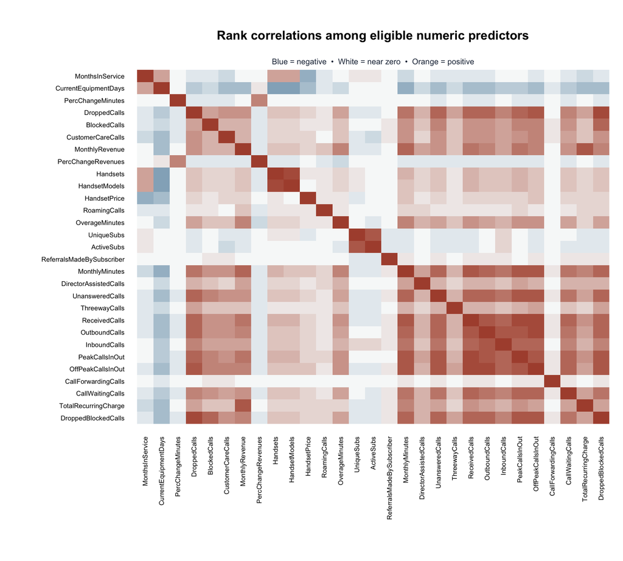

```r
correlation_colors <- colorRampPalette(c("#31688E", "#F7F9F9", "#AE503B"))(25)
field_positions <- seq_len(ncol(rho))
old_par <- par(mar = c(11, 11, 5.6, 1.1))
image(
  field_positions, field_positions, t(rho[nrow(rho):1, ]),
  zlim = c(-1, 1), col = correlation_colors, axes = FALSE,
  xlab = "", ylab = "", main = "Rank correlations among eligible numeric predictors"
)
axis(1, at = field_positions, labels = colnames(rho), las = 2,
     tick = FALSE, cex.axis = 0.64)
axis(2, at = field_positions, labels = rev(rownames(rho)), las = 1,
     tick = FALSE, cex.axis = 0.64)
mtext("Blue = negative  •  White = near zero  •  Orange = positive",
      side = 3, line = 0.25, cex = 0.76, col = chart_colors[["ink"]])
```

```r
par(old_par)
```

The screen flagged **36 predictor pairs**. The chart highlights pairs that directly inform the handset, network, subscription, usage, and billing comparisons.

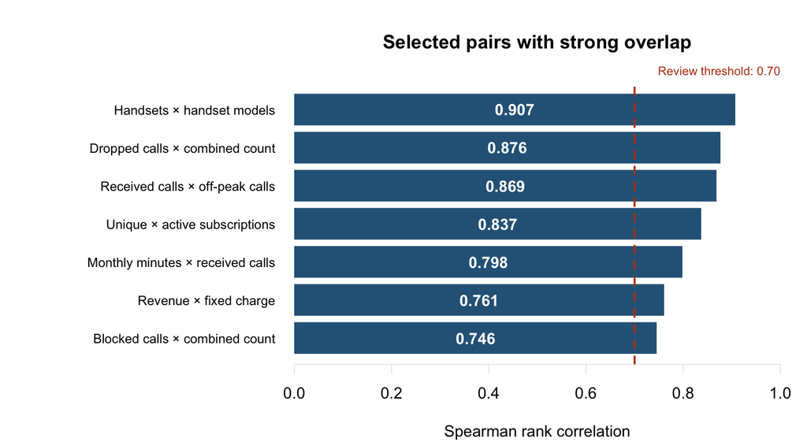

```r
spotlight <- data.frame(
  first = c("Handsets", "DroppedCalls", "ReceivedCalls", "UniqueSubs",
            "MonthlyMinutes", "MonthlyRevenue", "BlockedCalls"),
  second = c("HandsetModels", "DroppedBlockedCalls", "OffPeakCallsInOut",
             "ActiveSubs", "ReceivedCalls", "TotalRecurringCharge", "DroppedBlockedCalls"),
  label = c("Handsets × handset models", "Dropped calls × combined count",
            "Received calls × off-peak calls", "Unique × active subscriptions",
            "Monthly minutes × received calls", "Revenue × fixed charge",
            "Blocked calls × combined count")
)
indices <- cbind(match(spotlight$first, rownames(rho)),
                 match(spotlight$second, colnames(rho)))
spotlight$correlation <- rho[indices]
spotlight <- spotlight[order(spotlight$correlation), ]

old_par <- par(mar = c(4.3, 15.5, 4.4, 1.4))
positions <- barplot(
  spotlight$correlation, names.arg = spotlight$label, horiz = TRUE,
  las = 1, xlim = c(0, 1), xaxt = "n", border = NA,
  col = chart_colors[["blue"]], cex.names = 0.82,
  main = "Selected pairs with strong overlap",
  xlab = "Spearman rank correlation"
)
axis(1, at = seq(0, 1, 0.2), col = chart_colors[["grid"]])
abline(v = 0.70, col = chart_colors[["baseline"]], lty = 2, lwd = 2)
mtext("Review threshold: 0.70", side = 3, line = 0.25, adj = 1,
      col = chart_colors[["baseline"]], cex = 0.76)
text(spotlight$correlation / 2, positions,
     labels = sprintf("%.3f", spotlight$correlation), col = "white", font = 2)
```

```r
par(old_par)
```

### What this means

- **Handset counts.** At **0.907**, customers who rank high on handset count also tend to rank high on handset model count. Both counts stay in the broader challenger, while the focused model uses web capability.
- **Network quality.** The combined count overlaps with dropped calls (**0.876**) and blocked calls (**0.746**). Replacing the separate counts with the combined field reduced 10% outreach lift from **1.364 to 1.347**. The focused model keeps the separate counts.
- **Subscriptions and billing.** Unique and active subscriptions rank customers similarly (**0.837**), and each describes a different part of the account. The focused model retains both based on the subscription-block validation. Monthly revenue and the fixed plan charge also overlap (**0.761**). The model uses revenue and the billing gap to express account value and the difference from the fixed charge.

Strong correlation identifies fields worth comparing. A decision to remove one also depends on what it measures and whether the alternatives change ranking on the shared validation folds.

## Generated features

The sections below explain how the derived fields relate to churn. The descriptive tables use training records. The feature comparisons in `03_Variable_Selection.Rmd` use the shared validation folds.

### Churn outcome coding

`churn_flag` converts the recorded outcome to **1 for Yes** and **0 for No**. For example, a customer who left during the recorded observation period has a flag of 1. Averaging the flag within a group gives that group’s observed churn rate. In the training data, 11,033 of 38,285 customers had a flag of 1 (28.8%). This field is the outcome used to fit and evaluate the model.

**Concern.** The observation period is unverified, so the flag cannot support a claim about 30-day churn. It is used only as the outcome because it would be unavailable when scoring future customers.

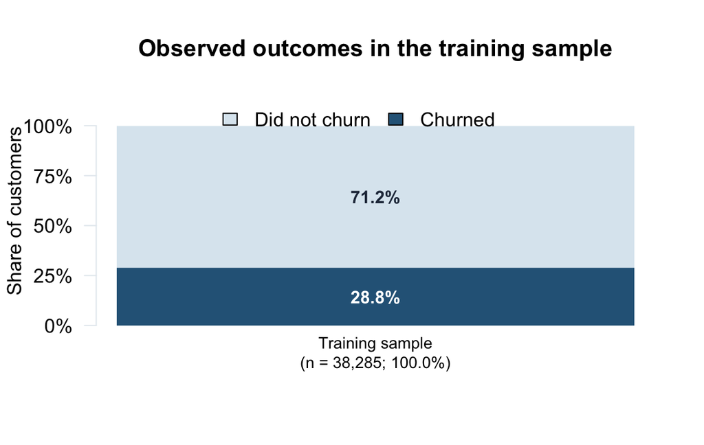

```r
outcome_summary <- churn_summary(rep("Training sample", nrow(training)))
plot_churn_composition(outcome_summary, "Observed outcomes in the training sample",
                       show_baseline = FALSE)
```

### Missing usage change and customer behavior

`PercChangeMinutes` compares usage across two recorded quarters. **`UsageChangeMissing = 1` when that value is missing and `0` when it is recorded.** For example, a blank usage-change field gets a 1, while a recorded change of zero gets a 0. The flag is created before imputation.

**Business hypothesis.** Accounts without a recorded change may differ from accounts with complete usage history. We check whether the missing usage and revenue changes occur on the same accounts, compare their churn rates, and examine how the missingness varies with tenure.

```r
training <- add_cell2cell_features(training)
change_status <- function(x) ifelse(is.na(x), "Missing", "Recorded")
knitr::kable(as.data.frame.matrix(with(training, table(
  `Usage change` = change_status(PercChangeMinutes),
  `Revenue change` = change_status(PercChangeRevenues)
))), caption = "Customer counts by usage-change status (rows) and revenue-change status (columns)")
```

Customer counts by usage-change status (rows) and revenue-change status (columns)

|  | Missing | Recorded |
| --- | --- | --- |
| Missing | 277 | 0 |
| Recorded | 0 | 38008 |

```r
usage_change_summary <- churn_summary(change_status(training$PercChangeMinutes))
knitr::kable(usage_change_summary,
             caption = "Churn by whether usage change was recorded",
             col.names = c("Group", "Customers", "Share of training sample", "Churned", "Churn (%)",
                           "Difference from training rate (percentage points)"))
```

Churn by whether usage change was recorded

| Group | Customers | Share of training sample | Churned | Churn (%) | Difference from training rate (percentage points) |
| --- | --- | --- | --- | --- | --- |
| Missing | 277 | 0.7% | 157 | 56.7 | 27.9 |
| Recorded | 38008 | 99.3% | 10876 | 28.6 | -0.2 |

```r
missing_by_tenure <- aggregate(
  cbind(customers = rep(1, nrow(training)), changes_missing = training$UsageChangeMissing),
  by = list(tenure = tenure), FUN = sum
)
knitr::kable(missing_by_tenure)
```

| tenure | customers | changes_missing |
| --- | --- | --- |
| (-Inf,6] | 553 | 0 |
| (6,12] | 12213 | 32 |
| (12,24] | 16084 | 90 |
| (24,36] | 7264 | 105 |
| (36, Inf] | 2171 | 50 |

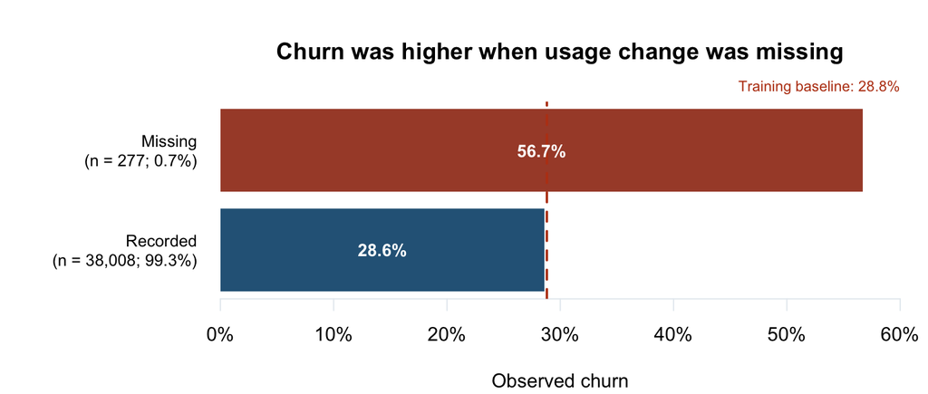

```r
plot_churn_comparison(usage_change_summary, "Churn was higher when usage change was missing")
```

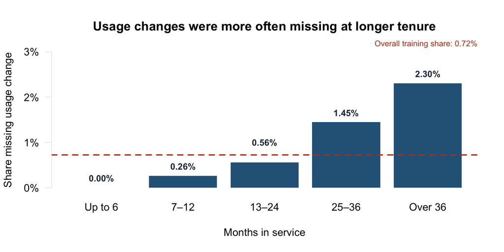

```r
missing_pct <- 100 * missing_by_tenure$changes_missing / missing_by_tenure$customers
overall_missing_pct <- 100 * mean(training$UsageChangeMissing)
positions <- barplot(
  missing_pct, names.arg = c("Up to 6", "7–12", "13–24", "25–36", "Over 36"),
  ylim = c(0, 3), yaxt = "n", border = NA, col = chart_colors[["blue"]],
  main = "Usage changes were more often missing at longer tenure",
  xlab = "Months in service", ylab = "Share missing usage change"
)
ticks <- 0:3
axis(2, at = ticks, labels = paste0(ticks, "%"), las = 1, col = chart_colors[["grid"]])
abline(h = overall_missing_pct, col = chart_colors[["baseline"]], lty = 2, lwd = 2)
mtext(sprintf("Overall training share: %.2f%%", overall_missing_pct),
      side = 3, line = 0.25, adj = 1, col = chart_colors[["baseline"]], cex = 0.76)
label_heights <- ifelse(abs(missing_pct - overall_missing_pct) < 0.25,
                        pmax(missing_pct, overall_missing_pct + 0.07), missing_pct)
text(positions, label_heights, labels = sprintf("%.2f%%", missing_pct),
     pos = 3, font = 2, col = chart_colors[["ink"]], cex = 0.85)
```

#### What this means

Both quarter changes are missing for the same 277 training customers. Their observed churn rate was 56.7%, compared with 28.6% for the 38,008 customers with both changes recorded. Adding the missingness flag raised 10% lift from **1.364 to 1.412**. In the focused follow-up, it raised 10% lift from **1.435 to 1.467** and improved lift in every fold. It is included in the primary logistic handoff alongside the interaction, subject to confirming scoring-time availability.

**Concern.** The flag may reflect how usage data were collected. Its association with churn could change if the recording process changes. Use at scoring depends on when the missing status becomes known.

### Dropped calls relative to usage

`DroppedCalls` counts interrupted calls. `MonthlyMinutes` measures usage. We calculate **`DroppedCallRate = 100 × DroppedCalls / MonthlyMinutes`**. For example, four dropped calls and 200 minutes give a rate of two per 100 minutes. The rate is missing when either input is missing, minutes are zero or negative, or the drop count is negative.

**Business hypothesis.** Adjusting for usage may help distinguish frequent interruptions from the higher number of opportunities for interruptions on a heavily used line. The table compares churn across rate bands.

```r
drop_rate_band <- cut(
  training$DroppedCallRate,
  breaks = c(-Inf, 0, 1, 5, Inf),
  labels = c("0", "Over 0 to 1", "Over 1 to 5", "Over 5")
)
drop_rate_summary <- churn_summary(drop_rate_band)
knitr::kable(
  drop_rate_summary,
  caption = "Observed churn by provisional dropped calls per 100 minutes",
  col.names = c("Rate band", "Customers", "Share of training sample", "Churned", "Churn (%)",
                "Difference from training rate (percentage points)"),
  format.args = list(big.mark = ",")
)
```

Observed churn by provisional dropped calls per 100 minutes

| Rate band | Customers | Share of training sample | Churned | Churn (%) | Difference from training rate (percentage points) |
| --- | --- | --- | --- | --- | --- |
| 0 | 5,228 | 13.7% | 1,538 | 29.4 | 0.6 |
| Over 0 to 1 | 15,232 | 39.8% | 4,012 | 26.3 | -2.5 |
| Over 1 to 5 | 16,046 | 41.9% | 4,685 | 29.2 | 0.4 |
| Over 5 | 1,116 | 2.9% | 409 | 36.6 | 7.8 |
| Missing | 663 | 1.7% | 389 | 58.7 | 29.9 |

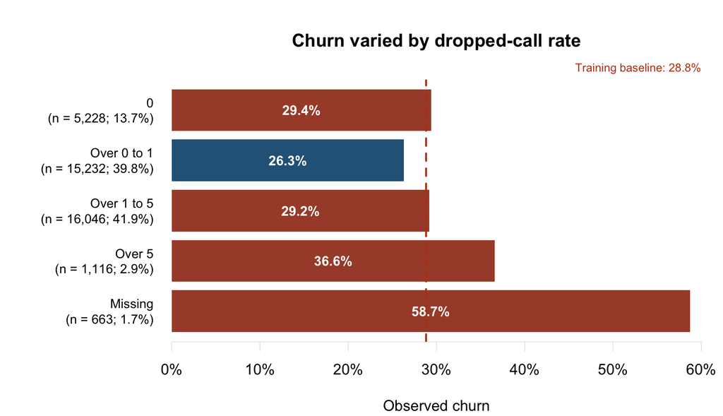

```r
plot_churn_comparison(drop_rate_summary, "Churn varied by dropped-call rate")
```

#### What this means

Observed churn was **36.6%** in the highest rate band, compared with **26.3%** in the band above zero and up to one. The group with an unavailable rate had **58.7%** churn. A missing rate can result from unusable inputs, so that group has a distinct interpretation. The rate raised 10% lift from **1.373 to 1.400** compared with the model that already included dropped calls and monthly minutes. It remains exploratory pending confirmation of the measurement windows.

**Concern.** The dictionary gives no explicit observation window for `DroppedCalls`. Interpreting the ratio as drops per 100 minutes depends on confirming that both fields cover comparable periods. Very low usage can also magnify the rate from a small number of dropped calls.

### Subscription gap and customer engagement

`UniqueSubs` counts distinct subscriptions associated with a customer account. `ActiveSubs` counts subscriptions that are currently active. We calculate the subscription gap as **`InactiveSubs = UniqueSubs − ActiveSubs`**. An account with five distinct subscriptions and three active subscriptions has a gap of two.

**Business hypothesis.** A larger gap may signal a weaker relationship with Cell2Cell and higher churn risk. More active lines may reflect a stronger relationship with the provider. We compare observed churn in the training data across gaps of zero, one, and two or more lines.

```r
gap_band <- cut(
  training$InactiveSubs,
  breaks = c(-Inf, 0, 1, Inf),
  labels = c("0 lines", "1 line", "2 or more lines")
)
gap_summary <- churn_summary(gap_band)
knitr::kable(
  gap_summary,
  caption = "Observed churn by subscription gap in the training data",
  col.names = c("Subscription gap", "Customers", "Share of training sample", "Churned", "Churn (%)",
                "Difference from training rate (percentage points)"),
  format.args = list(big.mark = ",")
)
```

Observed churn by subscription gap in the training data

| Subscription gap | Customers | Share of training sample | Churned | Churn (%) | Difference from training rate (percentage points) |
| --- | --- | --- | --- | --- | --- |
| 0 lines | 33,321 | 87.0% | 9,306 | 27.9 | -0.9 |
| 1 line | 3,736 | 9.8% | 1,266 | 33.9 | 5.1 |
| 2 or more lines | 1,228 | 3.2% | 461 | 37.5 | 8.7 |

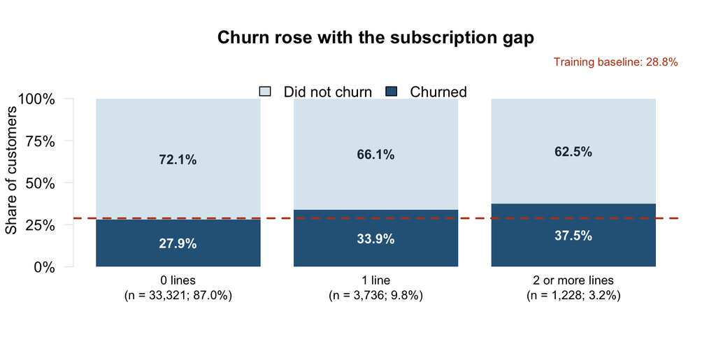

```r
plot_churn_composition(gap_summary, "Churn rose with the subscription gap")
```

Each bar represents 100% of its group. The dashed line shows the overall training churn rate. The labels show each group’s count (`n`) and its share of the training sample.

#### What this means

Observed churn increased from **27.9%** for accounts with no gap to **33.9%** for a gap of one and **37.5%** for a gap of two or more. Adding the gap to the benchmark increased 10% lift from **1.364 to 1.429**. In the focused follow-up, keeping active lines and replacing the other count with the gap reproduced the original results. Using the gap alone gave mixed fold results, so the handoff retains the original counts.

**Concern.** The snapshot leaves the timing and reasons for inactive subscriptions unknown. The gap is also determined entirely by the two subscription counts. Including all three as linear terms would duplicate information in the focused model.

### Nonlinear tenure and the customer relationship

`MonthsInService` measures time with the carrier. The model uses **`splines::ns(MonthsInService, df = 3)`** to represent tenure with three terms that allow the churn relationship to curve. The curve is learned from the fitting rows of each fold.

**Business hypothesis.** Churn risk may rise at some stages of the relationship and level off or fall at others. The tenure table in the Milestone 1 analysis shows observed churn of **18.6%** up to six months, **31.0%** above 12 through 24 months, and **27.4%** beyond 36 months. That pattern supports testing a curve.

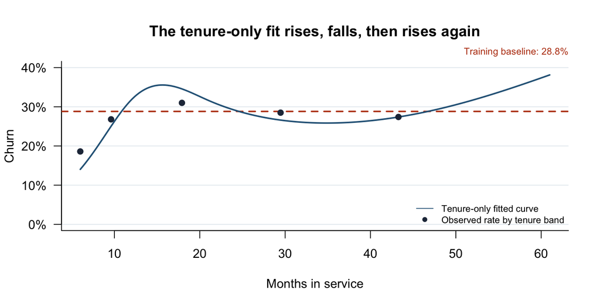

```r
tenure_data <- data.frame(months = training$MonthsInService, churn = churned)
tenure_only_model <- glm(churn ~ splines::ns(months, df = 3),
                         data = tenure_data, family = binomial())
tenure_grid <- data.frame(months = seq(min(tenure_data$months, na.rm = TRUE),
                                      max(tenure_data$months, na.rm = TRUE),
                                      length.out = 200))
fitted_churn <- 100 * predict(tenure_only_model, newdata = tenure_grid, type = "response")
band_midpoints <- tapply(tenure_data$months, tenure, mean)
vertical_ticks <- pretty(range(0, fitted_churn, tenure_summary$churn_pct))
plot(tenure_grid$months, fitted_churn, type = "n", bty = "l", yaxt = "n",
     ylim = range(vertical_ticks), xlab = "Months in service", ylab = "Churn",
     main = "The tenure-only fit rises, falls, then rises again")
abline(h = vertical_ticks, col = chart_colors[["grid"]])
axis(2, at = vertical_ticks, labels = paste0(vertical_ticks, "%"), las = 1)
add_churn_baseline()
lines(tenure_grid$months, fitted_churn, col = chart_colors[["blue"]], lwd = 2)
points(band_midpoints, tenure_summary$churn_pct, pch = 19, col = chart_colors[["ink"]])
legend("bottomright", legend = c("Tenure-only fitted curve", "Observed rate by tenure band"),
       lty = c(1, 0), pch = c(NA, 19), col = chart_colors[c("blue", "ink")],
       cex = 0.74, bty = "n")
```

The dots use each band’s average tenure and observed churn rate. The final dot pools all customers with more than 36 months of tenure. The late rise in the curve is a fitted estimate using tenure alone on the training data. Its predictive contribution would require a comparison with linear tenure on the shared validation folds.

**Concern.** The fitted curve is sensitive to the smaller groups at the ends of the tenure range. Tenure measures elapsed time, and the data have no contract renewal dates to explain the shape of the curve.

### Tenure and equipment age together

`CurrentEquipmentDays` measures how long a customer has used the current handset. The interaction adds **`splines::ns(MonthsInService, df = 3):CurrentEquipmentDays`** alongside the existing tenure and equipment-age terms. This lets the association between equipment age and churn vary with tenure.

**Business hypothesis.** An older handset may have a different association with churn for a newer customer than for a long-standing account. Each heatmap cell shows the churn rate within one tenure and equipment-age group.

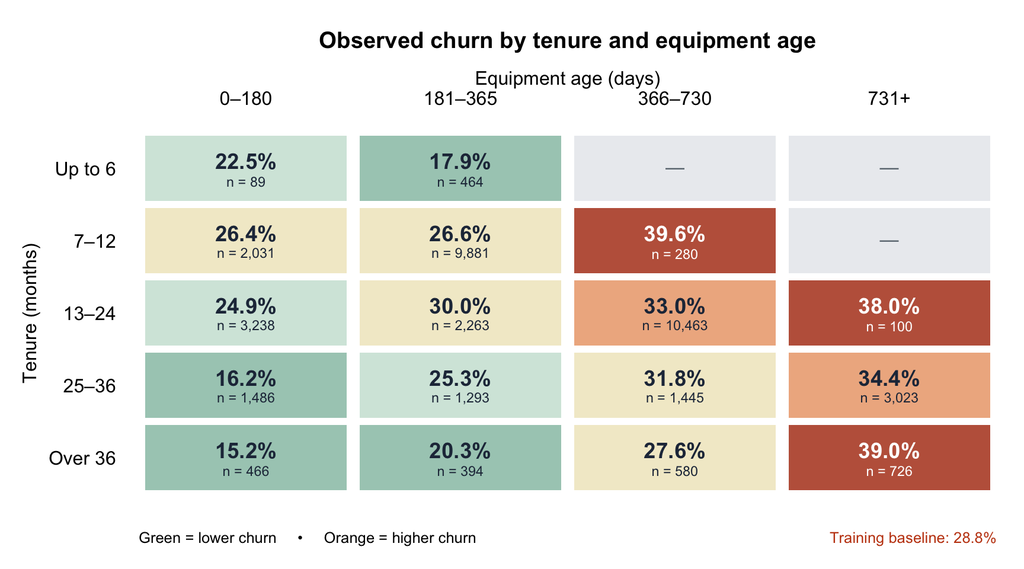

```r
segment_counts <- table(tenure, equipment)
segment_churned <- table(tenure[churned], equipment[churned])
segment_rates <- ifelse(segment_counts > 0, 100 * segment_churned / segment_counts, NA)
tenure_labels <- c("Up to 6", "7–12", "13–24", "25–36", "Over 36")
equipment_labels <- levels(equipment)

palette <- c("#A8CCBF", "#D4E7DD", "#F2EBCF", "#EFB48F", "#BF624A")
rate_bands <- matrix(
  cut(segment_rates - 100 * baseline,
      breaks = c(-Inf, -8, -3, 3, 8, Inf), labels = FALSE),
  nrow = nrow(segment_rates)
)

old_par <- par(mar = c(3.3, 6.1, 5.8, 1.2))
plot.new()
plot.window(xlim = c(0.5, 4.5), ylim = c(0.5, 5.5), xaxs = "i", yaxs = "i")
for (i in seq_len(nrow(segment_counts))) {
  row_y <- nrow(segment_counts) - i + 1
  for (j in seq_len(ncol(segment_counts))) {
    count <- segment_counts[i, j]
    band <- rate_bands[i, j]
    fill <- if (count > 0) palette[band] else "#EBEDF0"
    ink <- if (count > 0 && band == 5L) "#FFFFFF" else "#243247"
    rect(j - 0.47, row_y - 0.45, j + 0.47, row_y + 0.45,
         col = fill, border = NA)
    if (count > 0) {
      text(j, row_y + 0.10, sprintf("%.1f%%", segment_rates[i, j]),
           col = ink, font = 2, cex = 1.15)
      text(j, row_y - 0.18, paste0("n = ", format(count, big.mark = ",")),
           col = ink, cex = 0.73)
    } else {
      text(j, row_y, "—", col = "#626E78")
    }
  }
}
axis(3, at = seq_along(equipment_labels), labels = equipment_labels, tick = FALSE)
axis(2, at = rev(seq_along(tenure_labels)), labels = tenure_labels,
     tick = FALSE, las = 1)
mtext("Equipment age (days)", side = 3, line = 1.9)
mtext("Tenure (months)", side = 2, line = 4.3)
title("Observed churn by tenure and equipment age", line = 3.7)
mtext(sprintf("Training baseline: %.1f%%", 100 * baseline),
      side = 1, line = 1.35, adj = 1, col = "#C34412", cex = 0.8)
mtext("Green = lower churn     •     Orange = higher churn",
      side = 1, line = 1.35, adj = 0, cex = 0.8)
```

```r
par(old_par)
```

Gray cells (—) have no observed customers. The chart omits 63 training records missing tenure or equipment age. The middle color marks rates within three percentage points of the overall training baseline.

#### What this means

For customers with 13–24 months of tenure, observed churn was **24.9%** with equipment aged 0–180 days and **33.0%** at 366–730 days. Adding the tenure-by-equipment interaction to the benchmark increased 10% lift from **1.364 to 1.427**. The focused follow-up kept both main effects. Adding the interaction alone gave mixed results across folds at 10%, while adding it alongside the missingness flag improved lift across every fold and cutoff. The primary logistic handoff includes both additions.

#### Equipment age among customers with more than three years of tenure

The chart isolates the last row of the heatmap. Each bar shows the observed churn rate for one equipment-age group within that tenure band.

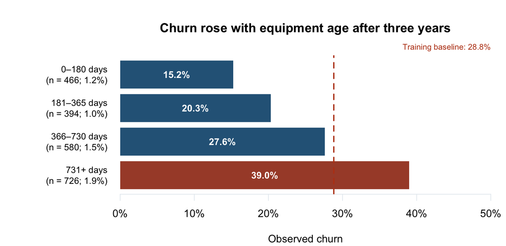

```r
long_tenure_row <- nrow(segment_counts)
long_tenure_counts <- as.vector(segment_counts[long_tenure_row, ])
long_tenure_summary <- data.frame(
  group = paste(equipment_labels, "days"),
  customers = long_tenure_counts,
  training_share = sprintf("%.1f%%", 100 * long_tenure_counts / nrow(training)),
  churn_pct = as.vector(segment_rates[long_tenure_row, ])
)
plot_churn_comparison(long_tenure_summary, "Churn rose with equipment age after three years")
```

Churn rose from **15.2%** for equipment aged 0–180 days (466 customers) to **39.0%** for equipment aged 731 days or more (726 customers), a difference of **23.8 percentage points**. The group with the oldest equipment was also the only one above the overall training churn rate of 28.8%. This supports retaining equipment age and screening its interaction with tenure. The subgroup chart alone does not establish a cutoff for outreach.

**Concern.** Some combinations have few customers, so their rates are less stable. The interaction also adds model terms, so any improvement needs to hold up on validation folds. This comparison cannot establish whether offering an upgrade would reduce churn.

### Billing gap and plan fit

`MonthlyRevenue` is the recorded average monthly bill. `TotalRecurringCharge` is the fixed monthly plan charge. For each account, we subtract the fixed charge from the recorded bill. **`billing_gap = MonthlyRevenue − TotalRecurringCharge`** measures the difference in USD per month.

| Recorded monthly bill | Fixed monthly charge | Calculation | Interpretation |
| --- | --- | --- | --- |
| $80 | $60 | 80 − 60 = **$20** | The bill is $20 above the fixed charge. |
| $80 | $80 | 80 − 80 = **$0** | The bill equals the fixed charge. |
| $50 | $60 | 50 − 60 = **−$10** | The bill is $10 below the fixed charge. |
| Missing | $60 | **`NA`** | The gap cannot be calculated without both values. |

The first two examples have the same $80 bill but different gaps because their plans have different fixed charges. The calculation preserves negative values. A gap of zero means both recorded amounts are equal. When either amount is missing, the gap remains `NA` in EDA. In cross-validation, the modeling notebook fills missing gaps using the median gap from the fitting rows for that fold.

**Business hypothesis.** Customers whose bills differ from their fixed charge may have a different churn profile. The chart and summary table group accounts by whether the gap is below, equal to, or above zero. The focused model uses the signed dollar amount, so a gap of $5 and a gap of $50 remain different values in the model.

```r
billing_band <- factor(
  sign(training$billing_gap),
  levels = c(-1, 0, 1),
  labels = c("Below fixed charge", "Equal to fixed charge", "Above fixed charge")
)
billing_summary <- churn_summary(billing_band)
knitr::kable(
  billing_summary,
  caption = "Observed churn by billing gap direction",
  col.names = c("Revenue versus fixed charge", "Customers", "Share of training sample", "Churned",
                "Churn (%)", "Difference from training rate (percentage points)"),
  format.args = list(big.mark = ",")
)
```

Observed churn by billing gap direction

| Revenue versus fixed charge | Customers | Share of training sample | Churned | Churn (%) | Difference from training rate (percentage points) |
| --- | --- | --- | --- | --- | --- |
| Below fixed charge | 13,613 | 35.6% | 3,541 | 26.0 | -2.8 |
| Equal to fixed charge | 807 | 2.1% | 276 | 34.2 | 5.4 |
| Above fixed charge | 23,743 | 62.0% | 7,163 | 30.2 | 1.4 |
| Missing | 122 | 0.3% | 53 | 43.4 | 14.6 |

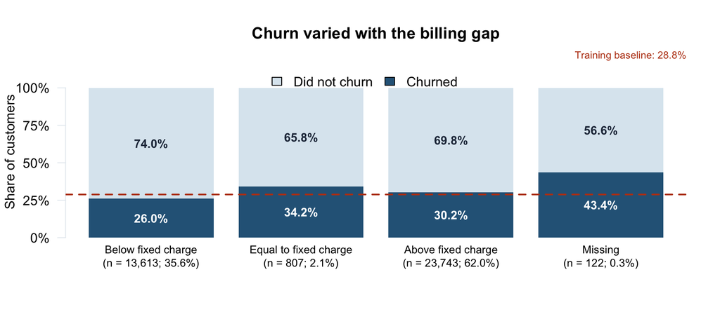

```r
plot_churn_composition(billing_summary, "Churn varied with the billing gap")
```

#### What this means

Observed churn was **26.0%** below the fixed charge and **30.2%** above it. The smaller group with equal revenue and fixed charge had **34.2%** churn.

#### Why use the gap if both original fields are available?

With both billing amounts observed, ordinary logistic regression with linear terms can represent the same relationship using either `MonthlyRevenue` and `TotalRecurringCharge` or `MonthlyRevenue` and `billing_gap`. The fixed charge can always be recovered as `MonthlyRevenue − billing_gap`. For example, an $80 bill and a $20 gap imply a $60 fixed charge.

The gap makes the comparison with the plan charge easier to interpret. Cross-validation checks whether that representation changes outreach ranking under the actual preprocessing. At 10% outreach capacity, lift was **1.364** with the gap and **1.363** with the fixed charge. Fold-specific imputation can produce small differences when source amounts are missing. The focused model retains the gap for its business interpretation, given the nearly identical validation results.

**Concern.** The gap can reflect multiple billing components. Identifying specific fees or estimating margin requires itemized billing and cost data. Using the gap with both original amounts as linear terms would also create perfect multicollinearity wherever all three values are available.

## Revenue exposure

The revenue exposure total sums recorded monthly bills for training customers who churned. Coverage is the share of historical churners whose bill amount is available.

> **Historical monthly revenue exposure in the training sample**

> **$633,652 USD**

> Sum of recorded monthly revenue for historical churners.

```r
knitr::kable(
  data.frame(
    `Historical churners` = churner_count,
    `With recorded revenue` = observed_churner_revenue,
    `Without recorded revenue` = missing_churner_revenue,
    `Revenue coverage` = sprintf("%.2f%%", revenue_coverage_pct),
    check.names = FALSE
  ),
  format.args = list(big.mark = ",")
)
```

| Historical churners | With recorded revenue | Without recorded revenue | Revenue coverage |
| --- | --- | --- | --- |
| 11,033 | 10,980 | 53 | 99.52% |

### Median monthly revenue by churn outcome

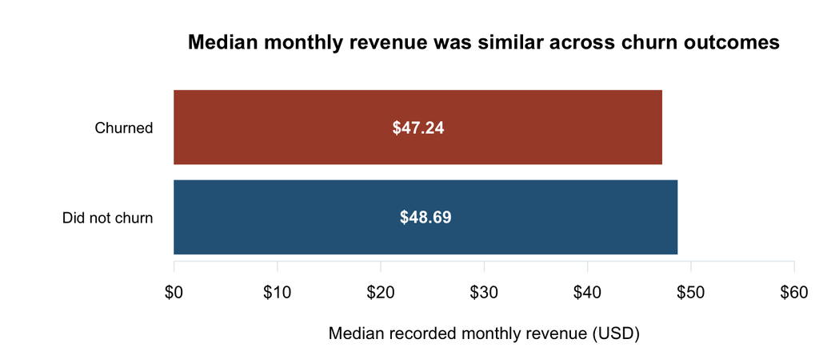

```r
old_par <- par(mar = c(4.2, 8.5, 4.1, 1.2))
medians <- rev(outcome_medians)
positions <- barplot(
  medians, horiz = TRUE, las = 1, border = NA, xaxt = "n",
  xlim = c(0, 60), col = chart_colors[c("blue", "high")],
  main = "Median monthly revenue was similar across churn outcomes",
  xlab = "Median recorded monthly revenue (USD)", cex.names = 0.9
)
ticks <- seq(0, 60, 10)
axis(1, at = ticks, labels = paste0("$", ticks), col = chart_colors[["grid"]])
text(medians / 2, positions, labels = sprintf("$%.2f", medians),
     col = "white", font = 2)
```

```r
par(old_par)
```

#### What this means

Median monthly revenue differed by about **$1.45**. The similar medians make a case for assessing churn risk and account value together when prioritizing outreach.

### Revenue exposure by customer group

The tables break down coverage and exposure by churn status, tenure, equipment age, and revenue tier.

```r
segment_groups <- list("Churn status" = ifelse(churned, "Churned", "Did not churn"),
                       "Tenure" = tenure, "Equipment age" = equipment,
                       "Recorded revenue tier" = revenue)
for (label in names(segment_groups)) {
  group <- addNA(as.factor(segment_groups[[label]]), ifany = TRUE)
  segments <- split(seq_len(nrow(training)), group, drop = TRUE)
  exposure <- do.call(rbind, lapply(segments, function(rows) {
    value <- training$MonthlyRevenue[rows]
    observed_churn <- churned[rows]
    data.frame(
      customers = length(rows),
      revenue_observed = sum(!is.na(value)),
      revenue_coverage = sprintf("%.1f%%", 100 * mean(!is.na(value))),
      median_revenue_usd = if (all(is.na(value))) NA_real_ else median(value, na.rm = TRUE),
      churners = sum(observed_churn),
      churners_with_revenue = sum(observed_churn & !is.na(value)),
      churner_revenue_usd = if (any(observed_churn & !is.na(value))) {
        sum(value[observed_churn], na.rm = TRUE)
      } else NA_real_
    )
  }))
  cat("\n\n**", label, "**\n\n", sep = "")
  print(knitr::kable(exposure, digits = 2))
}
```

**Churn status**

|  | customers | revenue_observed | revenue_coverage | median_revenue_usd | churners | churners_with_revenue | churner_revenue_usd |
| --- | --- | --- | --- | --- | --- | --- | --- |
| Churned | 11033 | 10980 | 99.5% | 47.24 | 11033 | 10980 | 633652.3 |
| Did not churn | 27252 | 27183 | 99.7% | 48.69 | 0 | 0 | NA |

**Tenure**

|  | customers | revenue_observed | revenue_coverage | median_revenue_usd | churners | churners_with_revenue | churner_revenue_usd |
| --- | --- | --- | --- | --- | --- | --- | --- |
| (-Inf,6] | 553 | 553 | 100.0% | 50.79 | 103 | 103 | 7170.57 |
| (6,12] | 12213 | 12211 | 100.0% | 49.38 | 3277 | 3275 | 196554.58 |
| (12,24] | 16084 | 16069 | 99.9% | 47.86 | 4991 | 4980 | 290224.08 |
| (24,36] | 7264 | 7181 | 98.9% | 46.70 | 2068 | 2036 | 108214.05 |
| (36, Inf] | 2171 | 2149 | 99.0% | 49.58 | 594 | 586 | 31489.02 |

**Equipment age**

|  | customers | revenue_observed | revenue_coverage | median_revenue_usd | churners | churners_with_revenue | churner_revenue_usd |
| --- | --- | --- | --- | --- | --- | --- | --- |
| 0–180 | 7310 | 7290 | 99.7% | 62.68 | 1675 | 1672 | 134758.88 |
| 181–365 | 14295 | 14275 | 99.9% | 49.93 | 3796 | 3786 | 224761.83 |
| 366–730 | 12768 | 12734 | 99.7% | 42.22 | 4188 | 4169 | 216329.43 |
| 731+ | 3849 | 3801 | 98.8% | 35.15 | 1361 | 1340 | 56736.92 |

**Recorded revenue tier**

|  | customers | revenue_observed | revenue_coverage | median_revenue_usd | churners | churners_with_revenue | churner_revenue_usd |
| --- | --- | --- | --- | --- | --- | --- | --- |
| Negative | 3 | 3 | 100.0% | -5.86 | 0 | 0 | NA |
| Under $31 | 7606 | 7606 | 100.0% | 25.50 | 2392 | 2392 | 53665.03 |
| $31 to <$61 | 18259 | 18259 | 100.0% | 42.83 | 5180 | 5180 | 228698.32 |
| $61 to <$101 | 8218 | 8218 | 100.0% | 76.72 | 2227 | 2227 | 172521.50 |
| $101+ | 4077 | 4077 | 100.0% | 131.42 | 1181 | 1181 | 178767.45 |

### What this means

Historical revenue exposure describes the recorded bills associated with past churn. For the financial handoff, a modeled churn probability of 0.40 paired with $100 monthly revenue gives $40 of probability-weighted monthly revenue exposure for the modeled event. Incremental retained contribution requires treatment effectiveness, margin, retained duration, and outreach and offer costs.